# Enrichment Analysis for Deiodinase Activity

Kimberly Truong

2024-07-19

For full transparency and reproducibility, this Rmd file shows all the enrichment calculations performed and their results for completeness. This can be found as a Supplemental File under Truong et al. (in preparation).

# Data Import and Environment

```r
rm(list=ls())
library(data.table)
library(dplyr)
library(tidyr)
library(ggplot2)
library(ggrepel)
library(ggvenn)
library(cowplot)
library(viridis)
library(RColorBrewer)
library(colorspace)
library(scales)
library(ggpubr)
library(openxlsx)
library(readxl)

load('./data/invitrodb_v3_5_thyroid_data.RData', verbose = T)
```

```
## Loading objects:
##   ace
##   ace.thyroid
##   cytotox
##   gene
##   mc5
##   mc5.hitc1
##   sc1
##   sc2
```

```r
# create a `not in` operator
`%notin%` <- Negate(`%in%`)
```

# Overview of Classes

## meta data

```r
# DIO/IYD assays
deiod.meta <- ace.thyroid[thyroid_related_target == 'Deiodinases',
                          .(aeid, aenm = assay_component_endpoint_name)]

aenm.abbrevs <- c('DIO1', 'DIO2', 'DIO3', 'IYD')

# ignore amphibian assays
h.deiod.aeids <- deiod.meta[grepl("\\w+h(DIO|IYD)\\w+", deiod.meta$aenm), aeid]
h.deiod.aenm <- deiod.meta[grepl("\\w+h(DIO|IYD)\\w+", deiod.meta$aenm), aenm]
names(h.deiod.aeids) <- aenm.abbrevs
names(h.deiod.aenm) <- aenm.abbrevs
```

## Hitcall Matrix

```r
# get hitcall data from sc/mc for DIO/IYD assays
long.mc5 <- mc5[!is.na(dsstox_substance_id) & aeid %in% h.deiod.aeids,
                .(dsstox_substance_id, aenm, hitc)]
long.sc2 <- sc2[!is.na(dsstox_substance_id) & aeid %in% h.deiod.aeids,
                .(dsstox_substance_id, aenm, hitc)]

# combine mc/sc data
long_all <- merge.data.table(long.sc2, long.mc5,
                             by = c("dsstox_substance_id", "aenm"),
                             all = T)
setnames(long_all, old = c("hitc.x", "hitc.y"),
         new = c("sc.hitc", "mc.hitc"))

# if tested in both, take hitc from mc; otherwise, take hitc from sc
long_hitc_final <- long_all %>%
  rowwise() %>%
  mutate(hitc = ifelse(!is.na(mc.hitc), mc.hitc, sc.hitc))

# form a hitcall matrix of all 2007 tested chems
M.hitc <- long_hitc_final %>%
  select(dsstox_substance_id, aenm, hitc) %>%
  pivot_wider(names_from = aenm, values_from = hitc) %>%
  as.data.frame()

M.hitc$chnm <- sc2$chnm[match(M.hitc$dsstox_substance_id, sc2$dsstox_substance_id)]
M.hitc <- M.hitc[, c("dsstox_substance_id", "chnm", h.deiod.aenm)]

row.names(M.hitc) <- M.hitc$dsstox_substance_id
M.hitc <- M.hitc[, -1]
```

## Hitcall Distribution

```r
# load updated classifications from Richard - 9/5/23
new.classified <- read_excel(file.path("./data", "chem_classifications.xlsx")) %>%
  as.data.table()

# move subset of QACs from "Expert" to "ClassyFire" group
new.classified[class_type == "Expert" & chosen_class == "Quaternary ammonium salts", class_type := "ClassyFire"]

# subset down to DIO/IYD test chems
classified_dt <- new.classified[dtxsid %in% rownames(M.hitc)]
setnames(classified_dt, "dtxsid", "dsstox_substance_id")

# match chemical order with M.hitc for 1-1 correspondence
classified_dt <- classified_dt[match(rownames(M.hitc), classified_dt$dsstox_substance_id), ]
identical(rownames(M.hitc), classified_dt$dsstox_substance_id)
```

```
## [1] TRUE
```

```r
counts <- classified_dt[, .N, keyby = .(class_type, chosen_class)][
  order(-N), .SD, keyby = .(class_type)
]

setDT(long_hitc_final)

# add selectivity as a column to long_hitc_final for better interpretation of hits
mc.deiod <- mc5[aeid %in% h.deiod.aeids & !is.na(dsstox_substance_id), .(chnm, aenm, modl_acc, modl_ga),
                by = .(aeid, dsstox_substance_id)]
mc.deiod[is.na(modl_acc), modl_acc := 5]
mc.deiod$cytomed <- cytotox$cytotox_median_log[match(mc.deiod$dsstox_substance_id, cytotox$dsstox_substance_id)]

# positive controls for DIO2/3/IYD are missing cytotox points
mc.deiod[is.na(cytomed)]
```

| aeid | dsstox_substance_id | chnm | aenm | modl_acc | modl_ga | cytomed |
| --- | --- | --- | --- | --- | --- | --- |
| 2532 | DTXSID00893171 | Xanthohumol | CCTE_GLTED_hDIO2_dn | -1.331134 | -0.6280615 | NA |
| 2533 | DTXSID00893171 | Xanthohumol | CCTE_GLTED_hDIO3_dn | -1.593697 | -0.7844713 | NA |
| 3032 | DTXSID80863216 | 3-Nitro-L-tyrosine | CCTE_GLTED_hIYD_dn | -2.228763 | -1.6355295 | NA |

```r
mc.deiod[is.na(cytomed), cytomed := 3]
mc.deiod[, selectivity := cytomed - pmin(modl_acc, 5)]
```

Impute cytotox median AC50 values for Xanthohumol and 3-Nitro-L-tyrosine to 3 (log10 uM).

```r
long_hitc_final2 <- merge.data.table(long_hitc_final,
                                     mc.deiod[, .(dsstox_substance_id, aenm, modl_acc, modl_ga, selectivity)],
                                     by = c("dsstox_substance_id", "aenm"),
                                     all.x = T)

# use selectivity as a stricter threshold for hitcall determination
long_hitc_final2[selectivity < 0.3, hitc := 0]

# merging hitcalls with class information
merged_dat <- merge.data.table(long_hitc_final,
                               classified_dt[, .(dsstox_substance_id, name, class_type, chosen_class)],
                               by = c("dsstox_substance_id"),
                               all.x = T)

for (i in 1:length(h.deiod.aenm)) {
  merged_dat[aenm == h.deiod.aenm[i], assay := names(h.deiod.aenm)[i] ]
}

# total number of chems tested in each assay (before classification)
merged_dat[, Nchems := length(dsstox_substance_id), keyby = aenm]
setnames(merged_dat, "Nchems", "Ntested")

# How many were classified in each assay? should be ALL thx to Richard
merged_dat[!is.na(chosen_class), .( Nclassified = length(dsstox_substance_id) ),
           keyby = aenm]
```

| aenm | Nclassified |
| --- | --- |
| CCTE_GLTED_hDIO1_dn | 1962 |
| CCTE_GLTED_hDIO2_dn | 1962 |
| CCTE_GLTED_hDIO3_dn | 1962 |
| CCTE_GLTED_hIYD_dn | 1969 |

```r
# distribution of pos/neg chems with classifications for each assay
hitc.dist <- merged_dat[, .( numChems = length(dsstox_substance_id) ),
           keyby = .(aenm, Ntested, hitc)]
hitc.dist[, hitrate := numChems/Ntested, by = .(aenm, hitc)]
hitc.dist
```

| aenm | Ntested | hitc | numChems | hitrate |
| --- | --- | --- | --- | --- |
| CCTE_GLTED_hDIO1_dn | 1962 | 0 | 1716 | 0.8746177 |
| CCTE_GLTED_hDIO1_dn | 1962 | 1 | 246 | 0.1253823 |
| CCTE_GLTED_hDIO2_dn | 1962 | 0 | 1634 | 0.8328236 |
| CCTE_GLTED_hDIO2_dn | 1962 | 1 | 328 | 0.1671764 |
| CCTE_GLTED_hDIO3_dn | 1962 | 0 | 1630 | 0.8307849 |
| CCTE_GLTED_hDIO3_dn | 1962 | 1 | 332 | 0.1692151 |
| CCTE_GLTED_hIYD_dn | 1969 | 0 | 1748 | 0.8877603 |
| CCTE_GLTED_hIYD_dn | 1969 | 1 | 221 | 0.1122397 |

100% classified with new classification scheme.

## Class Composition by Assay

The top 25 classes (or groups of classes) for each chemical library are shown here. Classes that made up less than 1% of the library for that assay shown here were regrouped into a broader and related “Other [classes from Classyfire|Drugs|Expert chemicals|Pesticides|PFAS categories]” category.

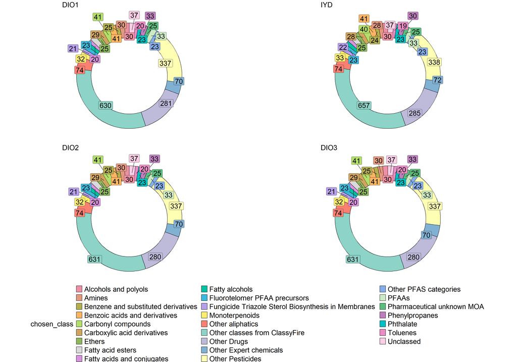

```r
# distribution of classes for test libraries
counts.by.aenm <- merged_dat[, .( .N ), keyby = .(aenm, class_type, chosen_class)]

# sorted by counts from highest to lowest, grouped by aenm
counts.by.aenm <- counts.by.aenm[order(-N), .SD, by = aenm]

# compute percentages per assay
counts.by.aenm[, total := sum(N), by = aenm]
counts.by.aenm[, fraction := N/total, by = .(aenm, chosen_class)]

# for classes with < 1% of chems, group them as 'Other (class_type)'
other_rows <- counts.by.aenm[fraction < 0.01,
                             .( chosen_class = paste("Other", class_type, sep = " "),
                                N = sum(N),
                                total = .SD[1, total], # denominator stays the same
                                fraction = sum(fraction)),
                             by = .(aenm, class_type)]

# relabel into broader categories
other_rows[chosen_class == "Other ClassyFire", chosen_class := "Other classes from ClassyFire"]
other_rows[chosen_class == "Other Pesticide", chosen_class := "Other Pesticides"]
other_rows[chosen_class == "Other Expert", chosen_class := "Other Expert chemicals"]
other_rows[chosen_class == "Other Drug", chosen_class := "Other Drugs"]
other_rows[chosen_class == "Other PFAS", chosen_class := "Other PFAS categories"]
other_rows[chosen_class == "Other Color", chosen_class := "Other colors"]

# append these rows and resort
counts.by.aenm <- rbindlist(list(counts.by.aenm, other_rows))
counts.by.aenm <- counts.by.aenm[order(-N), .SD, keyby = aenm]

# specify hole size for donut chart
hsize <- 3
counts.by.aenm[, x := hsize]
counts.by.aenm$aeid <- deiod.meta$aeid[match(counts.by.aenm$aenm, deiod.meta$aenm)]

# collect ggplot objects for ggpubr
plot_list <- list()

# form palette for top 25 classes from each ae
classes_to_plot <- counts.by.aenm[1:25, .SD, by = aenm][, unique(chosen_class)]
n.classes <- length(classes_to_plot)
class_pal <- c(brewer.pal(n = 12, name = "Set3"), qualitative_hcl(n.classes-12, palette = "set2"))

# to maintain consistent class-to-color map across subplots
counts.by.aenm$chosen_class <- as.factor(counts.by.aenm$chosen_class)
class_pal <- setNames(class_pal, classes_to_plot)

for(i in 1:4) {
  plot_list[[ names(h.deiod.aeids)[i] ]] <- ggplot(counts.by.aenm[aeid == h.deiod.aeids[i]][1:25], aes(x = hsize, y = fraction, fill = chosen_class)) +
    geom_col(color = 'black') +
    geom_label_repel(aes(label = N),
                     size = 7,
                     position = position_stack(vjust = 0.5),
                     show.legend = FALSE,
                     force_pull = 10) +
    scale_fill_manual(values = class_pal) +
    xlim(c(0.2, hsize + 0.5)) +
    coord_polar(theta = "y") +
    theme_void() +
    ggtitle(names(h.deiod.aeids)[i]) +
    theme(
      legend.title = element_text(size = 20),
      legend.text = element_text(size = 20),
      plot.title = element_text(size = 20)
    )
}

plot_list[["DIO1"]] <- plot_list[["DIO1"]] + guides(fill = guide_legend(nrow = 9, ncol = 3))

# combine the plots into one figure
class.comp <- ggarrange(plot_list$DIO1, plot_list$IYD,
                    plot_list$DIO2, plot_list$DIO3,
                    ncol = 2, nrow = 2,
                    common.legend = TRUE,
                    legend = 'bottom')
class.comp
```

```r
# ggsave(plot = class.comp,
#        units = "in",
#        dpi = 72,
#        width = 20, height = 14,
#        device = "jpg",
#        filename = "./doc/comptox-thyroid-httk/figures/supp/DIO_IYD_chem_library_composition.jpg")
```

# Class Enrichment

## Run Fisher’s test for every assay x class

```r
# form hitcall and class matrix
M.hitc2 <- M.hitc[, h.deiod.aenm] # take all assay columns
M.class <- as.data.frame.matrix(table(classified_dt$dsstox_substance_id,
                                           classified_dt$chosen_class))

# check that rows are ordered the same
identical(rownames(M.hitc2), rownames(M.class))
```

```
## [1] TRUE
```

```r
RunFisherTests <- function(M.hitc, M.ident, cf_level) {

  dfList <- list()
  num.aeids <- ncol(M.hitc)

  # run tests only on classes of sufficient size (n >= 3)
  cs = colSums(M.ident)
  col.ind <- which(cs >= 3)

  for(i in 1:num.aeids) {
    dataft <- matrix(NA, ncol = 8, nrow = length(col.ind))

    for(j in 1:length(col.ind)) {

      # calculate entries of 2x2 table
      a <- sum(M.ident[, col.ind[[j]] ] * M.hitc[, i], na.rm = T)
      b <- sum(M.ident[, col.ind[[j]] ] * (1 - M.hitc[, i]), na.rm = T)
      c <- sum( (1 - M.ident[, col.ind[[j]] ]) * M.hitc[, i], na.rm = T)
      d <- sum( (1 - M.ident[, col.ind[[j]] ]) * (1 - M.hitc[, i]), na.rm = T)

      tf <- data.frame("active" = c(a,c), "inactive" = c(b, d),
                       row.names = paste(c('in', 'not in'), cf_level))

      fttf<- fisher.test(tf)

      dataft[j,] <- c(fttf$p.value, fttf$estimate, fttf$conf.int, a, b, c, d)

    }

    # construct the dataframe for each assay
    ft.outputs <- c("Pval","Odds_Ratio","Lower","Upper")
    ft.cells <- paste0(c('Actives in ', 'Inactives in ', 'Actives not in ', 'Inactives not in '), cf_level)

    colnames(dataft) <- c(ft.outputs, ft.cells)

    dataft<-data.frame(dataft, check.names = FALSE)

    dataft$padj<-p.adjust(dataft$Pval, method="fdr")
    dataft[, cf_level] <- names(col.ind)

    dataft <- dataft[, c(1:4,9,10,5:8)]

    dfList[[i]] <- dataft
  }

  # reorder rows by most significant results with OR
  dfList = lapply(dfList, function(x) arrange(x, padj, desc(Odds_Ratio)))

  return(dfList)
}

res <- RunFisherTests(M.hitc2, M.class, 'group')
```

## DIO1

For DIO1

| Pval | Odds_Ratio | Lower | Upper | padj | group | Actives in group | Inactives in group | Actives not in group | Inactives not in group |
| --- | --- | --- | --- | --- | --- | --- | --- | --- | --- |
| 0.0000231 | 42.7111064 | 5.1495406 | 1950.4429047 | 0.0033800 | Estrogen flavonoid | 6 | 1 | 240 | 1715 |
| 0.0000386 | 16.6762417 | 3.7765575 | 100.7212331 | 0.0033800 | Quaternary ammonium salts | 7 | 3 | 239 | 1713 |
| 0.0000826 | 21.3614515 | 3.7924053 | 216.9455955 | 0.0048163 | Herbicide Chloroacetamide Very Long-Chain Fatty Acid Synthesis inhibitor | 6 | 2 | 240 | 1714 |
| 0.0004964 | 10.6736721 | 2.5112253 | 51.8308497 | 0.0217192 | Estrogen nonsteroidal | 6 | 4 | 240 | 1712 |
| 0.0010899 | 28.2448681 | 2.7815095 | 1384.8677637 | 0.0317886 | Antibiotic polyketide | 4 | 1 | 242 | 1715 |
| 0.0010899 | 28.2448681 | 2.7815095 | 1384.8677637 | 0.0317886 | Insecticide Arylalkyl organothiophosphate AChE Inhibitor | 4 | 1 | 242 | 1715 |
| 0.0019501 | Inf | 2.8965972 | Inf | 0.0426586 | Aryl chlorides | 3 | 0 | 243 | 1716 |
| 0.0019501 | Inf | 2.8965972 | Inf | 0.0426586 | Fungicide Phthalimide Multi-site activity | 3 | 0 | 243 | 1716 |
| 0.0072497 | 5.9037294 | 1.4138688 | 23.4145767 | 0.1153357 | Bisphenol | 5 | 6 | 241 | 1710 |
| 0.0068402 | 4.7357105 | 1.3742904 | 15.0520307 | 0.1153357 | Insecticide Aryl organothiophosphate AChE Inhibitor | 6 | 9 | 240 | 1707 |
| 0.0070574 | 0.0000000 | 0.0000000 | 0.6466012 | 0.1153357 | Carbonyl compounds | 0 | 41 | 246 | 1675 |
| 0.0260963 | 0.0000000 | 0.0000000 | 0.9043474 | 0.3805717 | Alcohols and polyols | 0 | 30 | 246 | 1686 |
| 0.0430942 | 14.0219320 | 0.7274453 | 824.9556901 | 0.3969199 | Anilides | 2 | 1 | 244 | 1715 |
| 0.0430942 | 14.0219320 | 0.7274453 | 824.9556901 | 0.3969199 | Lineolic acids and derivatives | 2 | 1 | 244 | 1715 |
| 0.0430942 | 14.0219320 | 0.7274453 | 824.9556901 | 0.3969199 | Organometallic Hg | 2 | 1 | 244 | 1715 |
| 0.0430942 | 14.0219320 | 0.7274453 | 824.9556901 | 0.3969199 | Retinoid | 2 | 1 | 244 | 1715 |
| 0.0430942 | 14.0219320 | 0.7274453 | 824.9556901 | 0.3969199 | Thyroid hormone | 2 | 1 | 244 | 1715 |
| 0.0430942 | 14.0219320 | 0.7274453 | 824.9556901 | 0.3969199 | Tryptase inhibitor | 2 | 1 | 244 | 1715 |
| 0.0389029 | 4.0313648 | 0.8588912 | 15.9935326 | 0.3969199 | Sulfuric acid esters | 4 | 7 | 242 | 1709 |
| 0.0463707 | 5.2765205 | 0.7683196 | 31.4089393 | 0.4057435 | PFAA precursors | 3 | 4 | 243 | 1712 |
| 0.0527664 | 3.5251843 | 0.7709891 | 13.2794249 | 0.4397199 | 1-hydroxy-2-unsubstituted benzenoids | 4 | 8 | 242 | 1708 |
| 0.0574597 | 2.2723631 | 0.8755678 | 5.2720346 | 0.4570660 | PFAAs | 8 | 25 | 238 | 1691 |
| 0.0791136 | 7.0123087 | 0.5061477 | 97.1838883 | 0.5768699 | HMGCoA inhibitor | 2 | 2 | 244 | 1714 |
| 0.0791136 | 7.0123087 | 0.5061477 | 97.1838883 | 0.5768699 | PPARg agonist | 2 | 2 | 244 | 1714 |
| 0.0978861 | 0.0000000 | 0.0000000 | 1.3339212 | 0.6852027 | Fungicide Triazole Sterol Biosynthesis in Membranes | 0 | 21 | 246 | 1695 |
| 0.1051428 | 1.6649982 | 0.8452681 | 3.0747380 | 0.7076916 | Other aliphatics | 14 | 60 | 232 | 1656 |
| 0.1211546 | 4.6745339 | 0.3886038 | 40.9669562 | 0.7562077 | Antiviral | 2 | 3 | 244 | 1713 |
| 0.1198537 | 3.0116558 | 0.4992440 | 13.3048425 | 0.7562077 | Polymer unclassified | 3 | 7 | 243 | 1709 |
| 0.1253144 | 1.9546020 | 0.7629369 | 4.4473285 | 0.7562077 | Unclassed | 8 | 29 | 238 | 1687 |
| 0.1671538 | 3.5045293 | 0.3154710 | 24.6013135 | 0.8807429 | Benzothiazoles | 2 | 4 | 244 | 1712 |

[output cut: 145 more lines]

## DIO2

For DIO2

| Pval | Odds_Ratio | Lower | Upper | padj | group | Actives in group | Inactives in group | Actives not in group | Inactives not in group |
| --- | --- | --- | --- | --- | --- | --- | --- | --- | --- |
| 0.0000237 | 35.5383595 | 4.5380638 | 1591.5876342 | 0.0020731 | Herbicide Chloroacetamide Very Long-Chain Fatty Acid Synthesis inhibitor | 7 | 1 | 321 | 1633 |
| 0.0000187 | 20.3484965 | 4.0356747 | 197.1556111 | 0.0020731 | Estrogen nonsteroidal | 8 | 2 | 320 | 1632 |
| 0.0002609 | 11.8319707 | 2.6840144 | 71.2785633 | 0.0152194 | Quaternary ammonium salts | 7 | 3 | 321 | 1631 |
| 0.0006151 | 8.8705109 | 2.2398629 | 41.5664715 | 0.0269114 | Bisphenol | 7 | 4 | 321 | 1630 |
| 0.0046367 | Inf | 2.0658544 | Inf | 0.0901575 | Cinnamaldehydes | 3 | 0 | 325 | 1634 |
| 0.0046367 | Inf | 2.0658544 | Inf | 0.0901575 | Fungicide Phthalimide Multi-site activity | 3 | 0 | 325 | 1634 |
| 0.0046367 | Inf | 2.0658544 | Inf | 0.0901575 | Fungicide Thiocarbamate Multi-site activity | 3 | 0 | 325 | 1634 |
| 0.0046367 | Inf | 2.0658544 | Inf | 0.0901575 | Retinoid | 3 | 0 | 325 | 1634 |
| 0.0045821 | 8.4013791 | 1.6254644 | 54.3339076 | 0.0901575 | Organometallic Sn | 5 | 3 | 323 | 1631 |
| 0.0058732 | 0.0000000 | 0.0000000 | 0.6442248 | 0.1027815 | Alcohols and polyols | 0 | 30 | 328 | 1604 |
| 0.0145901 | 0.0000000 | 0.0000000 | 0.7851724 | 0.2321157 | Ethers | 0 | 25 | 328 | 1609 |
| 0.0166094 | 2.5411843 | 1.1009965 | 5.5324058 | 0.2422209 | PFAAs | 11 | 22 | 317 | 1612 |
| 0.0244546 | 4.1957891 | 1.0065655 | 16.6110128 | 0.3291963 | Sulfuric acid esters | 5 | 6 | 323 | 1628 |
| 0.0355920 | 7.5200279 | 0.8579640 | 90.4924956 | 0.4449004 | Antibiotic polyketide | 3 | 2 | 325 | 1632 |
| 0.0743575 | 10.0013972 | 0.5191722 | 589.0165789 | 0.5421898 | Aryl chlorides | 2 | 1 | 326 | 1633 |
| 0.0743575 | 10.0013972 | 0.5191722 | 589.0165789 | 0.5421898 | Fungicide Imidazole Sterol Biosynthesis in Membranes | 2 | 1 | 326 | 1633 |
| 0.0743575 | 10.0013972 | 0.5191722 | 589.0165789 | 0.5421898 | Lineolic acids and derivatives | 2 | 1 | 326 | 1633 |
| 0.0743575 | 10.0013972 | 0.5191722 | 589.0165789 | 0.5421898 | Organometallic Hg | 2 | 1 | 326 | 1633 |
| 0.0743575 | 10.0013972 | 0.5191722 | 589.0165789 | 0.5421898 | Tryptase inhibitor | 2 | 1 | 326 | 1633 |
| 0.0624905 | 5.0124666 | 0.6683670 | 37.5891629 | 0.5421898 | Insecticide Organophosphate AChE Inhibitor | 3 | 3 | 325 | 1631 |
| 0.0546515 | 1.7646789 | 0.9746905 | 3.0705207 | 0.5421898 | Other aliphatics | 19 | 55 | 309 | 1579 |
| 0.0737918 | 0.1754905 | 0.0042803 | 1.0693795 | 0.5421898 | Carboxylic acid derivatives | 1 | 28 | 327 | 1606 |
| 0.0474688 | 0.1693344 | 0.0041352 | 1.0289678 | 0.5421898 | Amines | 1 | 29 | 327 | 1605 |
| 0.0570147 | 0.0000000 | 0.0000000 | 1.1277798 | 0.5421898 | Organosilicon compounds | 0 | 18 | 328 | 1616 |
| 0.1324759 | 5.0001685 | 0.3612311 | 69.3203126 | 0.5944431 | Adrenergic beta agonist | 2 | 2 | 326 | 1632 |
| 0.1324759 | 5.0001685 | 0.3612311 | 69.3203126 | 0.5944431 | Benzofuranones | 2 | 2 | 326 | 1632 |
| 0.1324759 | 5.0001685 | 0.3612311 | 69.3203126 | 0.5944431 | Biphenyls and derivatives | 2 | 2 | 326 | 1632 |
| 0.1324759 | 5.0001685 | 0.3612311 | 69.3203126 | 0.5944431 | Cinnamic acids and derivatives | 2 | 2 | 326 | 1632 |
| 0.1324759 | 5.0001685 | 0.3612311 | 69.3203126 | 0.5944431 | Glyceryl | 2 | 2 | 326 | 1632 |
| 0.1324759 | 5.0001685 | 0.3612311 | 69.3203126 | 0.5944431 | Halopyridines | 2 | 2 | 326 | 1632 |

[output cut: 145 more lines]

## DIO3

For DIO3

| Pval | Odds_Ratio | Lower | Upper | padj | group | Actives in group | Inactives in group | Actives not in group | Inactives not in group |
| --- | --- | --- | --- | --- | --- | --- | --- | --- | --- |
| 0.0000258 | 35.0155107 | 4.4714250 | 1568.3849512 | 0.0022538 | Herbicide Chloroacetamide Very Long-Chain Fatty Acid Synthesis inhibitor | 7 | 1 | 325 | 1629 |
| 0.0000258 | 35.0155107 | 4.4714250 | 1568.3849512 | 0.0022538 | Herbicide Triazine Inhibition of photosynthesis at PSll | 7 | 1 | 325 | 1629 |
| 0.0002825 | 11.6580174 | 2.6443576 | 70.1918987 | 0.0164770 | Quaternary ammonium salts | 7 | 3 | 325 | 1627 |
| 0.0006646 | 8.7402222 | 2.2071299 | 40.9936493 | 0.0290752 | Bisphenol | 7 | 4 | 325 | 1626 |
| 0.0048089 | Inf | 2.0358336 | Inf | 0.0935067 | Cinnamaldehydes | 3 | 0 | 329 | 1630 |
| 0.0048089 | Inf | 2.0358336 | Inf | 0.0935067 | Fungicide Phthalimide Multi-site activity | 3 | 0 | 329 | 1630 |
| 0.0048089 | Inf | 2.0358336 | Inf | 0.0935067 | Fungicide Thiocarbamate Multi-site activity | 3 | 0 | 329 | 1630 |
| 0.0048089 | Inf | 2.0358336 | Inf | 0.0935067 | Retinoid | 3 | 0 | 329 | 1630 |
| 0.0034970 | 19.8172136 | 1.9532697 | 973.2823962 | 0.0935067 | Antibiotic polyketide | 4 | 1 | 328 | 1629 |
| 0.0058108 | 0.0000000 | 0.0000000 | 0.6348346 | 0.1016884 | Alcohols and polyols | 0 | 30 | 332 | 1600 |
| 0.0144268 | 0.0000000 | 0.0000000 | 0.7737403 | 0.2295177 | Ethers | 0 | 25 | 332 | 1605 |
| 0.0162228 | 4.9635409 | 1.1353425 | 21.6981396 | 0.2365830 | Estrogen nonsteroidal | 5 | 5 | 327 | 1625 |
| 0.0319772 | 4.9514576 | 0.9173501 | 26.7263933 | 0.4304621 | Sesquiterpenoids | 4 | 4 | 328 | 1626 |
| 0.0364053 | 0.0000000 | 0.0000000 | 0.9367034 | 0.4550663 | Fungicide Triazole Sterol Biosynthesis in Membranes | 0 | 21 | 332 | 1609 |
| 0.0500416 | 3.9594490 | 0.7813475 | 18.4967236 | 0.5473302 | Insecticide Chlorinated cyclodiene GABA-gated chloride channel blocker | 4 | 5 | 328 | 1625 |
| 0.0473808 | 0.1729384 | 0.0042183 | 1.0537561 | 0.5473302 | Carboxylic acid derivatives | 1 | 28 | 331 | 1602 |
| 0.0567660 | 0.0000000 | 0.0000000 | 1.1113794 | 0.5843561 | Organosilicon compounds | 0 | 18 | 332 | 1612 |
| 0.0760683 | 9.8548166 | 0.5116482 | 580.4900579 | 0.6050890 | Aryl chlorides | 2 | 1 | 330 | 1629 |
| 0.0760683 | 9.8548166 | 0.5116482 | 580.4900579 | 0.6050890 | Depsides and depsidones | 2 | 1 | 330 | 1629 |
| 0.0760683 | 9.8548166 | 0.5116482 | 580.4900579 | 0.6050890 | Lineolic acids and derivatives | 2 | 1 | 330 | 1629 |
| 0.0760683 | 9.8548166 | 0.5116482 | 580.4900579 | 0.6050890 | Tryptase inhibitor | 2 | 1 | 330 | 1629 |
| 0.0644797 | 4.9394480 | 0.6586628 | 37.0397871 | 0.6050890 | Naphthols and derivatives | 3 | 3 | 329 | 1627 |
| 0.0990325 | 3.7031904 | 0.5399719 | 21.9987249 | 0.6956864 | Azobenzenes | 3 | 4 | 329 | 1626 |
| 0.0990325 | 3.7031904 | 0.5399719 | 21.9987249 | 0.6956864 | Progestogen | 3 | 4 | 329 | 1626 |
| 0.0993838 | 2.8253810 | 0.6030306 | 11.1867656 | 0.6956864 | Sulfuric acid esters | 4 | 7 | 328 | 1623 |
| 0.1353239 | 4.9275114 | 0.3559961 | 68.3007202 | 0.7400524 | Benzofuranones | 2 | 2 | 330 | 1628 |
| 0.1353239 | 4.9275114 | 0.3559961 | 68.3007202 | 0.7400524 | Cinnamic acids and derivatives | 2 | 2 | 330 | 1628 |
| 0.1353239 | 4.9275114 | 0.3559961 | 68.3007202 | 0.7400524 | Glyceryl | 2 | 2 | 330 | 1628 |
| 0.1353239 | 4.9275114 | 0.3559961 | 68.3007202 | 0.7400524 | HMGCoA inhibitor | 2 | 2 | 330 | 1628 |
| 0.1353239 | 4.9275114 | 0.3559961 | 68.3007202 | 0.7400524 | PPARg agonist | 2 | 2 | 330 | 1628 |

[output cut: 145 more lines]

## IYD

For IYD

| Pval | Odds_Ratio | Lower | Upper | padj | group | Actives in group | Inactives in group | Actives not in group | Inactives not in group |
| --- | --- | --- | --- | --- | --- | --- | --- | --- | --- |
| 0.0000061 | 28.4636401 | 5.3730297 | 280.6420376 | 0.0010623 | Insecticide Chlorinated cyclodiene GABA-gated chloride channel blocker | 7 | 2 | 214 | 1746 |
| 0.0000234 | 5.3920218 | 2.4265620 | 11.5894098 | 0.0020485 | PFAAs | 13 | 20 | 208 | 1728 |
| 0.0001176 | 16.1859485 | 3.4275574 | 100.8398210 | 0.0068621 | Quaternary ammonium salts | 6 | 3 | 215 | 1745 |
| 0.0005319 | 9.7038914 | 2.4453693 | 40.5850137 | 0.0232707 | Bisphenol | 6 | 5 | 215 | 1743 |
| 0.0009648 | 8.0855389 | 2.1411398 | 30.5397578 | 0.0337694 | 1-hydroxy-2-unsubstituted benzenoids | 6 | 6 | 215 | 1742 |
| 0.0025810 | 6.0609404 | 1.7157668 | 20.1290472 | 0.0752799 | Sulfuric acid esters | 6 | 8 | 215 | 1740 |
| 0.0075059 | 8.0204083 | 1.4828070 | 43.4152724 | 0.1641923 | Azobenzenes | 4 | 4 | 217 | 1744 |
| 0.0075059 | 8.0204083 | 1.4828070 | 43.4152724 | 0.1641923 | Sesquiterpenoids | 4 | 4 | 217 | 1744 |
| 0.0102784 | 5.0277195 | 1.2822072 | 17.6105803 | 0.1998587 | Polymer unclassified | 5 | 8 | 216 | 1740 |
| 0.0187767 | 5.3438713 | 1.1003303 | 22.7362664 | 0.3285916 | Estrogen nonsteroidal | 4 | 6 | 217 | 1742 |
| 0.0348474 | 15.9091055 | 0.8250675 | 935.4537166 | 0.5081920 | Cinnamaldehydes | 2 | 1 | 219 | 1747 |
| 0.0346557 | 5.9902639 | 0.8717473 | 35.6454134 | 0.5081920 | Insecticide Organochlorine Sodium channel modulator | 3 | 4 | 218 | 1744 |
| 0.0417969 | 0.0000000 | 0.0000000 | 1.0265154 | 0.5567561 | Alcohols and polyols | 0 | 30 | 221 | 1718 |
| 0.0445405 | 0.0000000 | 0.0000000 | 0.9263046 | 0.5567561 | Monoterpenoids | 0 | 33 | 221 | 1715 |
| 0.0509455 | 4.7909087 | 0.7389016 | 24.8072011 | 0.5943643 | Naphthalene sulfonic acids and derivatives | 3 | 5 | 218 | 1743 |
| 0.0645718 | 7.9564482 | 0.5740981 | 110.3150852 | 0.6364787 | Glyceryl | 2 | 2 | 219 | 1746 |
| 0.0596881 | 2.2251187 | 0.8675092 | 5.0701325 | 0.6364787 | Unclassed | 8 | 29 | 213 | 1719 |
| 0.0654664 | 0.0000000 | 0.0000000 | 1.1059679 | 0.6364787 | Carboxylic acid derivatives | 0 | 28 | 221 | 1720 |
| 0.0707826 | 2.4516147 | 0.8777795 | 5.9917977 | 0.6519450 | Phenylpropanes | 7 | 23 | 214 | 1725 |
| 0.0997871 | 5.3042310 | 0.4407893 | 46.5445100 | 0.8392775 | Phenylmethylamines | 2 | 3 | 219 | 1745 |
| 0.1007133 | 0.0000000 | 0.0000000 | 1.3077434 | 0.8392775 | Fatty alcohols | 0 | 24 | 221 | 1724 |
| 0.1388979 | 3.9767803 | 0.3578251 | 27.9474267 | 1.0000000 | Anilides | 2 | 4 | 219 | 1744 |
| 0.1388979 | 3.9767803 | 0.3578251 | 27.9474267 | 1.0000000 | Naphthols and derivatives | 2 | 4 | 219 | 1744 |
| 0.3004747 | 3.9632725 | 0.0669590 | 76.3259080 | 1.0000000 | Aryl chlorides | 1 | 2 | 220 | 1746 |
| 0.3004747 | 3.9632725 | 0.0669590 | 76.3259080 | 1.0000000 | Benzenediols | 1 | 2 | 220 | 1746 |
| 0.3004747 | 3.9632725 | 0.0669590 | 76.3259080 | 1.0000000 | Fungicide Anilinopyrimidine Amino Acid and Protein Synthesis | 1 | 2 | 220 | 1746 |
| 0.3004747 | 3.9632725 | 0.0669590 | 76.3259080 | 1.0000000 | Herbicide Triazolopyrimidine Acetolactate synthase inhibitor | 1 | 2 | 220 | 1746 |
| 0.3004747 | 3.9632725 | 0.0669590 | 76.3259080 | 1.0000000 | Lineolic acids and derivatives | 1 | 2 | 220 | 1746 |
| 0.3004747 | 3.9632725 | 0.0669590 | 76.3259080 | 1.0000000 | PPARg agonist | 1 | 2 | 220 | 1746 |
| 0.3004747 | 3.9632725 | 0.0669590 | 76.3259080 | 1.0000000 | Tryptase inhibitor | 1 | 2 | 220 | 1746 |

[output cut: 145 more lines]

## Table 6 of Truong et al.

```r
sig.classes <- lapply(res, function(df) {
  sig <- df %>%
    filter(padj < 0.05 & (Odds_Ratio > 3 | Odds_Ratio < 1/3)) %>%
    select(Pval, padj, Odds_Ratio, Lower, Upper, group, `Actives in group`, `Inactives in group`)
})

names(sig.classes) <- aenm.abbrevs

add.assay <- Map(function(df, name) {
  df$assay <- name
  df <- df[, c("assay", colnames(df)[colnames(df) != "assay"])]
  return(df)
}, sig.classes, names(sig.classes))

tb.paper <- bind_rows(add.assay)

# report pvalues with 2 sigfigs
tb.paper[, c("Pval", "padj")] <- signif(tb.paper[, c("Pval", "padj")], digits = 2)

# round other numerical values to 2 digits after decimal pt
tb.paper[, c("Odds_Ratio", "Lower", "Upper")] <- round(tb.paper[, c("Odds_Ratio", "Lower", "Upper")], digits = 2)
kable(tb.paper,  caption = "Summary of Significant Results across all Targets")
```

Summary of Significant Results across all Targets

| assay | Pval | padj | Odds_Ratio | Lower | Upper | group | Actives in group | Inactives in group |
| --- | --- | --- | --- | --- | --- | --- | --- | --- |
| DIO1 | 2.3e-05 | 0.0034 | 42.71 | 5.15 | 1950.44 | Estrogen flavonoid | 6 | 1 |
| DIO1 | 3.9e-05 | 0.0034 | 16.68 | 3.78 | 100.72 | Quaternary ammonium salts | 7 | 3 |
| DIO1 | 8.3e-05 | 0.0048 | 21.36 | 3.79 | 216.95 | Herbicide Chloroacetamide Very Long-Chain Fatty Acid Synthesis inhibitor | 6 | 2 |
| DIO1 | 5.0e-04 | 0.0220 | 10.67 | 2.51 | 51.83 | Estrogen nonsteroidal | 6 | 4 |
| DIO1 | 1.1e-03 | 0.0320 | 28.24 | 2.78 | 1384.87 | Antibiotic polyketide | 4 | 1 |
| DIO1 | 1.1e-03 | 0.0320 | 28.24 | 2.78 | 1384.87 | Insecticide Arylalkyl organothiophosphate AChE Inhibitor | 4 | 1 |
| DIO1 | 2.0e-03 | 0.0430 | Inf | 2.90 | Inf | Aryl chlorides | 3 | 0 |
| DIO1 | 2.0e-03 | 0.0430 | Inf | 2.90 | Inf | Fungicide Phthalimide Multi-site activity | 3 | 0 |
| DIO2 | 2.4e-05 | 0.0021 | 35.54 | 4.54 | 1591.59 | Herbicide Chloroacetamide Very Long-Chain Fatty Acid Synthesis inhibitor | 7 | 1 |
| DIO2 | 1.9e-05 | 0.0021 | 20.35 | 4.04 | 197.16 | Estrogen nonsteroidal | 8 | 2 |
| DIO2 | 2.6e-04 | 0.0150 | 11.83 | 2.68 | 71.28 | Quaternary ammonium salts | 7 | 3 |
| DIO2 | 6.2e-04 | 0.0270 | 8.87 | 2.24 | 41.57 | Bisphenol | 7 | 4 |
| DIO3 | 2.6e-05 | 0.0023 | 35.02 | 4.47 | 1568.38 | Herbicide Chloroacetamide Very Long-Chain Fatty Acid Synthesis inhibitor | 7 | 1 |
| DIO3 | 2.6e-05 | 0.0023 | 35.02 | 4.47 | 1568.38 | Herbicide Triazine Inhibition of photosynthesis at PSll | 7 | 1 |
| DIO3 | 2.8e-04 | 0.0160 | 11.66 | 2.64 | 70.19 | Quaternary ammonium salts | 7 | 3 |
| DIO3 | 6.6e-04 | 0.0290 | 8.74 | 2.21 | 40.99 | Bisphenol | 7 | 4 |
| IYD | 6.1e-06 | 0.0011 | 28.46 | 5.37 | 280.64 | Insecticide Chlorinated cyclodiene GABA-gated chloride channel blocker | 7 | 2 |
| IYD | 2.3e-05 | 0.0020 | 5.39 | 2.43 | 11.59 | PFAAs | 13 | 20 |
| IYD | 1.2e-04 | 0.0069 | 16.19 | 3.43 | 100.84 | Quaternary ammonium salts | 6 | 3 |
| IYD | 5.3e-04 | 0.0230 | 9.70 | 2.45 | 40.59 | Bisphenol | 6 | 5 |
| IYD | 9.6e-04 | 0.0340 | 8.09 | 2.14 | 30.54 | 1-hydroxy-2-unsubstituted benzenoids | 6 | 6 |

## Supplemental File 2

```r
# prep Excel output with tabs
names(res)  <- paste0(aenm.abbrevs, "-class")
res$`class annotations` = classified_dt
```

# Hits by Target

```r
# helper function to draw the Venn Diagram for an input class
# this only counts chemicals that were uniformly tested across all 4 targets
#' @hitc.class.dat is a dataframe or (data.table) with columns for DTXSID, classifications, aenm, and hitc
#' @class_var is the name (of character type) of the column corresponding to classifications
display_venn <- function(class, hitc.class.dat, class_var) {
  merged_datw <- dcast(hitc.class.dat, as.formula(paste("dsstox_substance_id +", class_var, "~ aenm")),
                       value.var = 'hitc')
  setDT(merged_datw)
  merged_datw$name <- classified_dt$name[match(merged_datw$dsstox_substance_id, classified_dt$dsstox_substance_id)]

  colnames(merged_datw)[colnames(merged_datw)%in% h.deiod.aenm] <- aenm.abbrevs
  merged_datw[, total_hits := DIO1 + DIO2 + DIO3 + IYD]
  merged_datw.tested4x <- merged_datw[complete.cases(merged_datw)]

  class_dat <- merged_datw.tested4x[get(class_var) == class]
  hit.freqs <- table(class_dat$total_hits)

  list_venn <- list(DIO1 = class_dat[DIO1 == 1, name],
                  DIO2 = class_dat[DIO2 == 1, name],
                  DIO3 = class_dat[DIO3 == 1, name],
                  IYD = class_dat[IYD == 1, name])

  venn_obj <- ggvenn(list_venn,
       show_percentage = FALSE,
       fill_color = c("#0073C2FF", "#EFC000FF", "#868686FF", "#CD534CFF"),
       text_size = 3,
       set_name_size = 3,
       stroke_size = 0.5) +
  annotate("text", x = 2, y = -0.5, label = ifelse(!is.na(hit.freqs["0"]), hit.freqs["0"], ""),
           size = 3)

  return(venn_obj)
}
```

## Odds Ratio == Inf

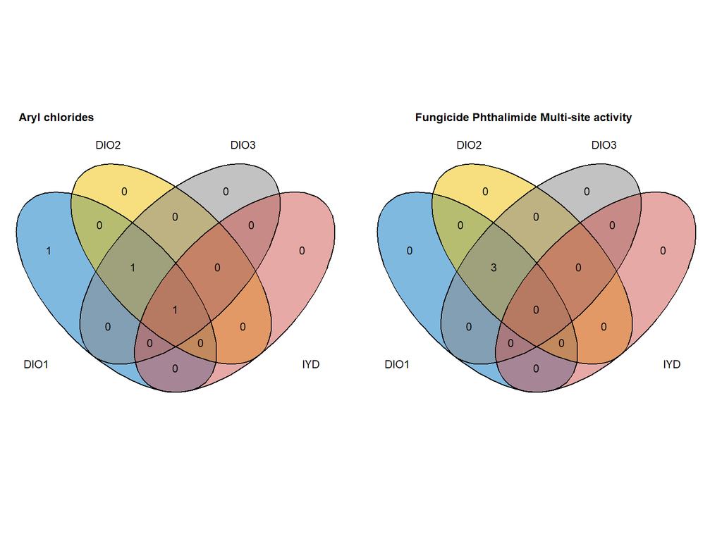

```r
# organize based on odds ratios
inf.or <- c("Aryl chlorides", "Fungicide Phthalimide Multi-site activity")

merged_dat.sel <- merge.data.table(long_hitc_final,
                        classified_dt[,.(dsstox_substance_id,name,class_type,chosen_class)],
                               by = c("dsstox_substance_id"),
                               all.x = T)

infor_list <- lapply(inf.or, display_venn, hitc.class.dat = merged_dat, class_var = "chosen_class")
names(infor_list) <- inf.or

# combine the plots into one figure
ggarrange(infor_list$`Aryl chlorides`, infor_list$`Fungicide Phthalimide Multi-site activity`,
          labels = names(infor_list),
          font.label = list(size = 9),
          hjust = -0.25,
          label.y = 0.8,
          nrow = 1, ncol = 2)
```

## Odds Ratio > 3

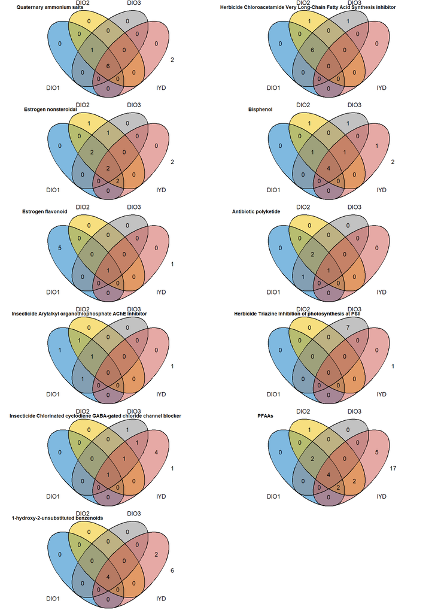

```r
sig.or <- c("Quaternary ammonium salts", "Herbicide Chloroacetamide Very Long-Chain Fatty Acid Synthesis inhibitor",
            "Estrogen nonsteroidal", "Bisphenol",
            "Estrogen flavonoid", "Antibiotic polyketide",
            "Insecticide Arylalkyl organothiophosphate AChE Inhibitor",
            "Herbicide Triazine Inhibition of photosynthesis at PSll",
            "Insecticide Chlorinated cyclodiene GABA-gated chloride channel blocker", "PFAAs",
            "1-hydroxy-2-unsubstituted benzenoids")

sigor_list <- lapply(sig.or, display_venn, hitc.class.dat = merged_dat, class_var = "chosen_class")
names(sigor_list) <- sig.or

sig.class.labels <- names(sigor_list)

# combine the plots into one figure
ggarrange(plotlist = sigor_list,
          labels = sig.class.labels,
          font.label = list(size = 7),
          label.y = 0.97,
          label.x = c(0, -0.20, 0.05, 0.10, 0.05, 0, -0.10, -0.08, -0.15, 0.15, -0.05),
          hjust = -0.25,
          nrow = 6, ncol = 2)
```

## Figure 3 of Truong et al.

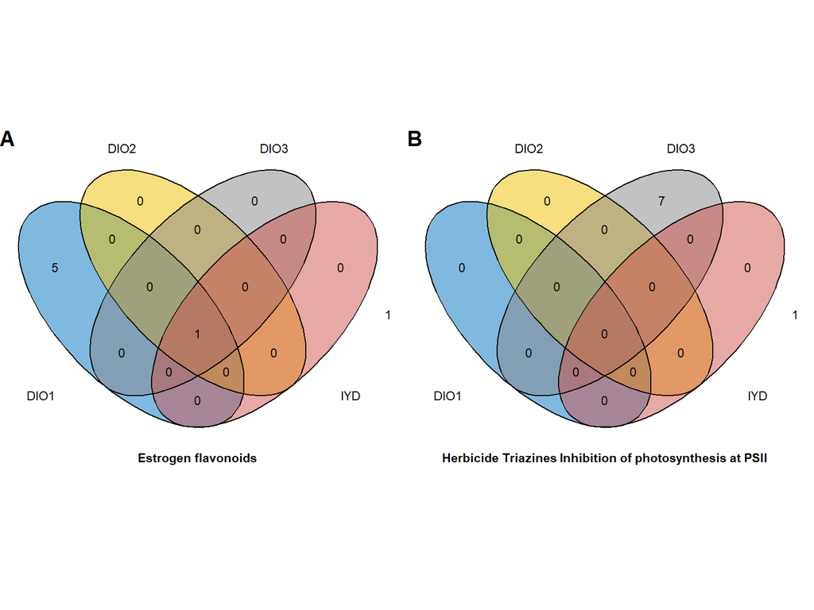

```r
# focus on triazines and estrogen flavonoids for paper
flavos.venn <- sigor_list$`Estrogen flavonoid` +
  annotate("text", x = 0, y = -2, label = "Estrogen flavonoids",
            size = 3, fontface= "bold")

triazine.venn <- sigor_list$`Herbicide Triazine Inhibition of photosynthesis at PSll` +
  annotate("text", x = 0, y = -2, label = "Herbicide Triazines Inhibition of photosynthesis at PSll",
            size = 3, fontface= "bold")

uniq.positives <- ggarrange(flavos.venn, triazine.venn,
          labels = c("A", "B"),
          font.label = list(size = 15),
          label.x = 0,
          label.y = 0.8,
          hjust = 0,
          nrow = 1, ncol = 2) +
  theme(plot.background = element_rect(fill = "white", color = "white"))

uniq.positives
```

```r
dev.off()
```

```r
ggsave(plot = uniq.positives,
       units = "mm",
       dpi = 300,
       width = 190, height = 152,
       device = "tiff",
       filename = "./figures/300dpi/uniq_positives_v2.tiff")

ggsave(plot = uniq.positives,
       units = "mm",
       dpi = 300,
       width = 190, height = 152,
       device = "png",
       filename = "./figures/uniq_positives_v2.png")
```

# Color/Spectral Interference

We wish to examine whether there is enriched activity (or inactivity) for specific groups of colored substances (e.g. C.I., FD&C, D&C, based on the specific color).

## Colors vs. non-colors

Color breakdown in the DIO/IYD testing library.

```r
is_color <- grepl("\\w+\\s(red|orange|yellow|green|blue|violet|black)\\s*\\w*", classified_dt$name, ignore.case = T)
classified_dt[!is_color, main_class := chosen_class]
classified_dt[is_color, main_class := "Colors"]

classified_dt[, new_class := chosen_class]

all_colors <- c("Red", "Orange", "Yellow", "Green", "Blue", "Violet", "Black")

for(k in seq_along(all_colors)) {
  classified_dt$new_class[which(grepl(paste0("\\w+\\s(", all_colors[k], ")\\s*\\w*"), classified_dt$name, ignore.case = T))] = all_colors[k]
}

# how many of each specific color
classified_dt[main_class == "Colors", .N, by = .(main_class, new_class)]
```

| main_class | new_class | N |
| --- | --- | --- |
| Colors | Blue | 6 |
| Colors | Orange | 6 |
| Colors | Yellow | 8 |
| Colors | Black | 2 |
| Colors | Red | 9 |
| Colors | Green | 1 |
| Colors | Violet | 2 |

```r
M.class2 <- as.data.frame.matrix(table(classified_dt$dsstox_substance_id,
                                           classified_dt$main_class))

res2 <- RunFisherTests(M.hitc2, M.class2[, "Colors", drop = FALSE], "group")
names(res2) <- aenm.abbrevs

res2 <- Map(function(df, name) {
  df$assay <- name
  df <- df[, c("assay", colnames(df)[colnames(df) != "assay"])]
  return(df)
}, res2, names(res2))

all_res <- bind_rows(res2)
```

## Results for colors vs. non-colors

For all assays

| assay | Pval | Odds_Ratio | Lower | Upper | padj | group | Actives in group | Inactives in group | Actives not in group | Inactives not in group |
| --- | --- | --- | --- | --- | --- | --- | --- | --- | --- | --- |
| DIO1 | 0.2678900 | 1.690450 | 0.5613094 | 4.278143 | 0.2678900 | Colors | 6 | 25 | 240 | 1691 |
| DIO2 | 0.0007306 | 3.701625 | 1.6494181 | 8.082131 | 0.0007306 | Colors | 13 | 18 | 315 | 1616 |
| DIO3 | 0.0029699 | 3.177040 | 1.3917025 | 6.972719 | 0.0029699 | Colors | 12 | 19 | 320 | 1611 |
| IYD | 0.0000067 | 6.353009 | 2.7948141 | 14.119985 | 0.0000067 | Colors | 13 | 17 | 208 | 1731 |

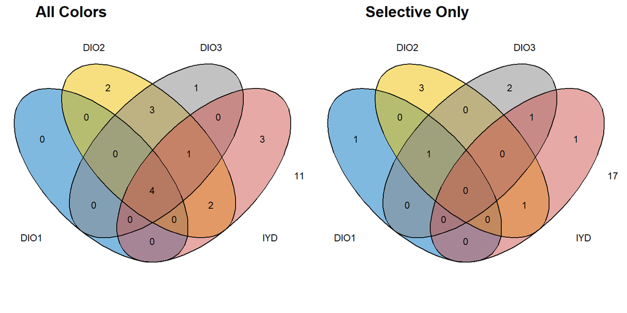

Venn Diagrams show results before and after applying a “selectivity” filter.

## Color-specific classes

```r
M.class3 <- as.data.frame.matrix(table(classified_dt$dsstox_substance_id,
                                           classified_dt$new_class))

res3 <- RunFisherTests(M.hitc2, M.class3[, all_colors], "group")
names(res3) <- aenm.abbrevs
```

## DIO1

For DIO1

| Pval | Odds_Ratio | Lower | Upper | padj | group | Actives in group | Inactives in group | Actives not in group | Inactives not in group |
| --- | --- | --- | --- | --- | --- | --- | --- | --- | --- |
| 0.1671538 | 3.5045293 | 0.3154710 | 24.601313 | 0.6686153 | Orange | 2 | 4 | 244 | 1712 |
| 0.4885849 | 1.7463273 | 0.0353301 | 17.735712 | 0.9771698 | Blue | 1 | 4 | 245 | 1712 |
| 1.0000000 | 1.1631568 | 0.0251881 | 9.649539 | 1.0000000 | Red | 1 | 6 | 245 | 1710 |
| 1.0000000 | 0.9965032 | 0.0220218 | 7.810076 | 1.0000000 | Yellow | 1 | 7 | 245 | 1709 |

## DIO2

For DIO2

| Pval | Odds_Ratio | Lower | Upper | padj | group | Actives in group | Inactives in group | Actives not in group | Inactives not in group |
| --- | --- | --- | --- | --- | --- | --- | --- | --- | --- |
| 0.0355920 | 7.520028 | 0.8579640 | 90.49250 | 0.1423681 | Blue | 3 | 2 | 325 | 1632 |
| 0.0961341 | 3.757931 | 0.5479218 | 22.32509 | 0.1805402 | Red | 3 | 4 | 325 | 1630 |
| 0.1354052 | 3.005085 | 0.4643878 | 15.52862 | 0.1805402 | Yellow | 3 | 5 | 325 | 1629 |
| 0.2643525 | 2.498471 | 0.2251265 | 17.51444 | 0.2643525 | Orange | 2 | 4 | 326 | 1630 |

## DIO3

For DIO3

| Pval | Odds_Ratio | Lower | Upper | padj | group | Actives in group | Inactives in group | Actives not in group | Inactives not in group |
| --- | --- | --- | --- | --- | --- | --- | --- | --- | --- |
| 0.0644797 | 4.939448 | 0.6586628 | 37.039787 | 0.1980649 | Orange | 3 | 3 | 329 | 1627 |
| 0.0990325 | 3.703190 | 0.5399719 | 21.998725 | 0.1980649 | Red | 3 | 4 | 329 | 1626 |
| 0.2010154 | 3.284110 | 0.2733031 | 28.790320 | 0.2680205 | Blue | 2 | 3 | 330 | 1627 |
| 0.6297011 | 1.639916 | 0.1611829 | 9.222986 | 0.6297011 | Yellow | 2 | 6 | 330 | 1624 |

## IYD

For IYD

| Pval | Odds_Ratio | Lower | Upper | padj | group | Actives in group | Inactives in group | Actives not in group | Inactives not in group |
| --- | --- | --- | --- | --- | --- | --- | --- | --- | --- |
| 0.0002965 | 20.142792 | 3.2738241 | 212.224944 | 0.0011859 | Red | 5 | 2 | 216 | 1746 |
| 0.0019318 | 16.046253 | 2.2845934 | 178.150291 | 0.0038636 | Blue | 4 | 2 | 217 | 1746 |
| 0.0997871 | 5.304231 | 0.4407893 | 46.544510 | 0.1330495 | Orange | 2 | 3 | 219 | 1745 |
| 1.0000000 | 0.000000 | 0.0000000 | 5.503411 | 1.0000000 | Yellow | 0 | 7 | 221 | 1741 |

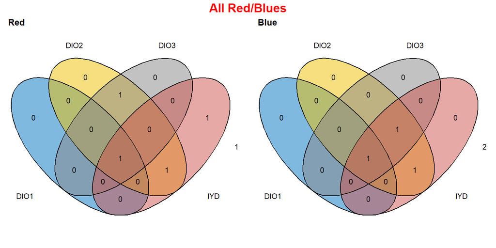

```r
sig.colors <- c("Red", "Blue")

new.merged.colors2 <- merge.data.table(long_hitc_final,
                               classified_dt[, .(dsstox_substance_id,class_type,new_class)],
                               by = c("dsstox_substance_id"),
                               all.x = T)

new.merged.colors2.sel <- merge.data.table(long_hitc_final2,
                               classified_dt[, .(dsstox_substance_id,class_type,new_class)],
                               by = c("dsstox_substance_id"),
                               all.x = T)

# before selectivity filter
sig.iyd.colors <- lapply(sig.colors, display_venn, hitc.class.dat = new.merged.colors2, class_var = "new_class")
names(sig.iyd.colors) <- sig.colors

# combine the plots into one figure
iyd.a <- ggarrange(plotlist = sig.iyd.colors,
          labels = names(sig.iyd.colors),
          font.label = list(size = 10),
          nrow = 1, ncol = 2)

# after selectivity filter
sig.iyd.colors2 <- lapply(sig.colors, display_venn, hitc.class.dat = new.merged.colors2.sel, class_var = "new_class")
names(sig.iyd.colors2) <- sig.colors

# combine the plots into one figure
iyd.b <- ggarrange(plotlist = sig.iyd.colors2,
          labels = names(sig.iyd.colors2),
          font.label = list(size = 10),
          nrow = 1, ncol = 2)

annotate_figure(iyd.a, top = text_grob("All Red/Blues",
               color = "red", face = "bold", size = 14))
```

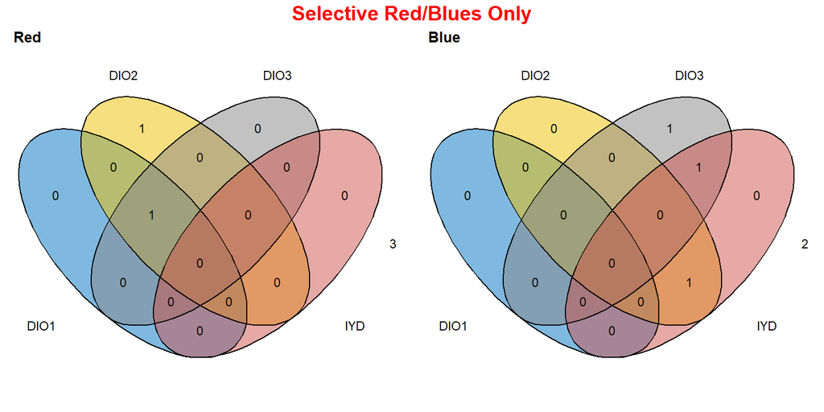

```r
annotate_figure(iyd.b, top = text_grob("Selective Red/Blues Only",
               color = "red", face = "bold", size = 14))
```

Venn Diagrams show results before and after applying a “selectivity” filter.

## Registered classes

```r
classified_dt[, new_class := chosen_class]
classified_dt[grep("^[F]*D&C", classified_dt$name),
              new_class := "(F)D&C"]
classified_dt[grep("C.I.", classified_dt$name), new_class := "C.I."]

M.class4 <- as.data.frame.matrix(table(classified_dt$dsstox_substance_id,
                                           classified_dt$new_class))

res4 <- RunFisherTests(M.hitc2, M.class4[, c("(F)D&C", "C.I.")], "group")
names(res4) <- aenm.abbrevs
```

## DIO1

DIO1: For registered classes

| Pval | Odds_Ratio | Lower | Upper | padj | group | Actives in group | Inactives in group | Actives not in group | Inactives not in group |
| --- | --- | --- | --- | --- | --- | --- | --- | --- | --- |
| 0.3311025 | 3.494327 | 0.0590515 | 67.456250 | 0.345855 | (F)D&C | 1 | 2 | 245 | 1714 |
| 0.3458550 | 1.558808 | 0.3805507 | 4.786131 | 0.345855 | C.I. | 4 | 18 | 242 | 1698 |

## DIO2

DIO2: For registered classes

| Pval | Odds_Ratio | Lower | Upper | padj | group | Actives in group | Inactives in group | Actives not in group | Inactives not in group |
| --- | --- | --- | --- | --- | --- | --- | --- | --- | --- |
| 0.4225349 | 2.493889 | 0.0421695 | 48.025744 | 0.4225349 | (F)D&C | 1 | 2 | 327 | 1632 |
| 0.2429139 | 1.883513 | 0.5989874 | 5.115433 | 0.4225349 | C.I. | 6 | 16 | 322 | 1618 |

## DIO3

DIO3: For registered classes

| Pval | Odds_Ratio | Lower | Upper | padj | group | Actives in group | Inactives in group | Actives not in group | Inactives not in group |
| --- | --- | --- | --- | --- | --- | --- | --- | --- | --- |
| 0.0802724 | 2.317707 | 0.7929122 | 6.096793 | 0.1605447 | C.I. | 7 | 15 | 325 | 1615 |
| 0.4267680 | 2.457913 | 0.0415593 | 47.330155 | 0.4267680 | (F)D&C | 1 | 2 | 331 | 1628 |

## IYD

IYD: For registered classes

| Pval | Odds_Ratio | Lower | Upper | padj | group | Actives in group | Inactives in group | Actives not in group | Inactives not in group |
| --- | --- | --- | --- | --- | --- | --- | --- | --- | --- |
| 0.0348474 | 15.909106 | 0.8250675 | 935.453717 | 0.0348474 | (F)D&C | 2 | 1 | 219 | 1747 |
| 0.0186756 | 3.453165 | 1.0759729 | 9.689231 | 0.0348474 | C.I. | 6 | 14 | 215 | 1734 |

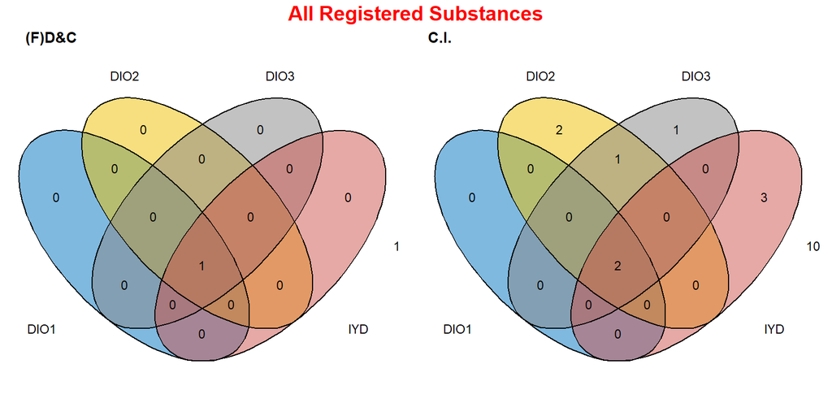

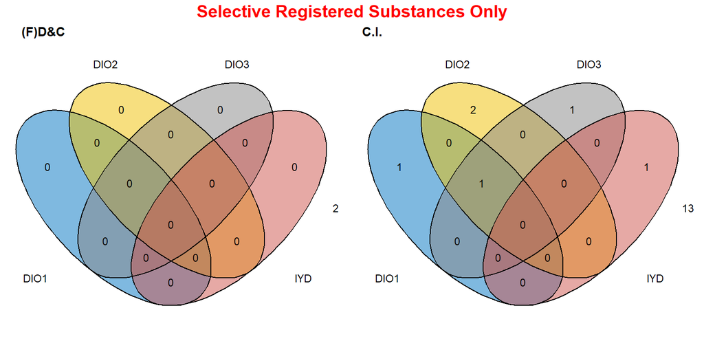

Venn Diagrams show results before and after applying a “selectivity” filter.

# ToxPrint Enrichment

## load ToxPrints

```r
toxprints <- fread("./data/DIO_IYD_testlib_invitrodb_v3_5_input_toxprints.csv")

# how many chems don't have ToxPrints?
head(toxprints[cid == ""])
```

| DTXSID | smiles | cid | atom:element_main_group | atom:element_metal_group_I_II | atom:element_metal_group_III | atom:element_metal_metalloid | atom:element_metal_poor_metal | atom:element_metal_transistion_metal | atom:element_noble_gas | bond:C#N_cyano_acylcyanide | bond:C#N_cyano_cyanamide | bond:C#N_cyano_cyanohydrin | bond:C#N_nitrile_ab-acetylenic | bond:C#N_nitrile_ab-unsaturated | bond:C#N_nitrile_generic | bond:C#N_nitrile_isonitrile | bond:C#N_nitrile | bond:C(~Z)~C~Q_a-haloalcohol | bond:C(~Z)~C~Q_a-halocarbonyl | bond:C(~Z)~C~Q_a-haloether | bond:C(~Z)~C~Q_a-haloketone_perhalo | bond:C(~Z)~C~Q_b-halocarbonyl | bond:C(~Z)~C~Q_haloamine_haloethyl_(N-mustard) | bond:C(~Z)~C~Q_halocarbonyl_dichloro_quinone_(1_2-) | bond:C(~Z)~C~Q_halocarbonyl_dichloro_quinone_(1_4-) | bond:C(~Z)~C~Q_halocarbonyl_dichloro_quinone_(1_5-) | bond:C(~Z)~C~Q_haloether_dibenzodioxin_1-halo | bond:C(~Z)~C~Q_haloether_dibenzodioxin_2-halo | bond:C(~Z)~C~Q_haloether_dibenzodioxin_dichloro_(2_7-) | … |
| --- | --- | --- | --- | --- | --- | --- | --- | --- | --- | --- | --- | --- | --- | --- | --- | --- | --- | --- | --- | --- | --- | --- | --- | --- | --- | --- | --- | --- | --- | --- |
| DTXSID0021175 |  |  | NA | NA | NA | NA | NA | NA | NA | NA | NA | NA | NA | NA | NA | NA | NA | NA | NA | NA | NA | NA | NA | NA | NA | NA | NA | NA | NA | … |
| DTXSID0026171 |  |  | NA | NA | NA | NA | NA | NA | NA | NA | NA | NA | NA | NA | NA | NA | NA | NA | NA | NA | NA | NA | NA | NA | NA | NA | NA | NA | NA | … |
| DTXSID0027852 |  |  | NA | NA | NA | NA | NA | NA | NA | NA | NA | NA | NA | NA | NA | NA | NA | NA | NA | NA | NA | NA | NA | NA | NA | NA | NA | NA | NA | … |
| DTXSID0027856 |  |  | NA | NA | NA | NA | NA | NA | NA | NA | NA | NA | NA | NA | NA | NA | NA | NA | NA | NA | NA | NA | NA | NA | NA | NA | NA | NA | NA | … |
| DTXSID0027983 |  |  | NA | NA | NA | NA | NA | NA | NA | NA | NA | NA | NA | NA | NA | NA | NA | NA | NA | NA | NA | NA | NA | NA | NA | NA | NA | NA | NA | … |
| DTXSID0028666 |  |  | NA | NA | NA | NA | NA | NA | NA | NA | NA | NA | NA | NA | NA | NA | NA | NA | NA | NA | NA | NA | NA | NA | NA | NA | NA | NA | NA | … |

```r
nrow(toxprints[cid == ""])
```

```
## [1] 82
```

82 chemicals did not have ToxPrints because they were either UVCBs or Markush structures.

## form matrices

```r
# subset to available ToxPrints
chemotype.cols <- colnames(toxprints)[colnames(toxprints) %notin% c("DTXSID", "smiles", "cid","M_COMPOUND_HISTORY_[STRING]","M_CORINA_SYMPHONY_ERRORS_[STRING]")]
M.chemotype.dt <- toxprints[cid != "", c("DTXSID", ..chemotype.cols)]

# add chemical names and classifications
M.chemotype.dt$name <- classified_dt$name[match(M.chemotype.dt$DTXSID, classified_dt$dsstox_substance_id)]
M.chemotype.dt$chosen_class <- classified_dt$chosen_class[match(M.chemotype.dt$DTXSID, classified_dt$dsstox_substance_id)]
M.chemotype.dt <- M.chemotype.dt[, c("DTXSID", "name", "chosen_class", chemotype.cols), with = FALSE]

M.chemotype <- as.data.frame(M.chemotype.dt[, c("DTXSID", ..chemotype.cols)])
rownames(M.chemotype) <- M.chemotype$DTXSID
M.chemotype <- M.chemotype[, -1]

M.hitc.tp <- M.hitc2[rownames(M.chemotype),]

# check that rows are ordered the same
identical(rownames(M.hitc.tp), rownames(M.chemotype))
```

```
## [1] TRUE
```

## run tests

```r
tp.res <- RunFisherTests(M.hitc.tp, M.chemotype, "group")
```

## significant for DIO1

For DIO1

| Pval | Odds_Ratio | Lower | Upper | padj | group | Actives in group | Inactives in group | Actives not in group | Inactives not in group |
| --- | --- | --- | --- | --- | --- | --- | --- | --- | --- |
| 0.0000003 | 6.9669239 | 3.2687022 | 14.7167791 | 0.0000514 | bond:CX_halide_alkyl-F_perfluoro_octyl | 16 | 18 | 209 | 1641 |
| 0.0000002 | 3.4984119 | 2.1773331 | 5.5215907 | 0.0000514 | chain:alkaneLinear_octyl_C8 | 32 | 75 | 193 | 1584 |
| 0.0000020 | 5.6873891 | 2.7449749 | 11.5462980 | 0.0001397 | chain:alkaneLinear_dodedyl_C12 | 16 | 22 | 209 | 1637 |
| 0.0000021 | 3.9012815 | 2.2114203 | 6.7149118 | 0.0001397 | bond:S~N_generic | 23 | 47 | 202 | 1612 |
| 0.0000128 | 3.0928471 | 1.8599708 | 5.0219248 | 0.0006373 | bond:CS_sulfide | 27 | 70 | 198 | 1589 |
| 0.0000234 | Inf | 6.8428548 | Inf | 0.0010354 | bond:CC(=O)C_ketone_alkene_cyclic_3-en-1-one | 5 | 0 | 220 | 1659 |
| 0.0000278 | 17.6687140 | 3.9985962 | 106.8452637 | 0.0011075 | ring:hetero_[6_6]*O_benzopyrone*(1_4-) | 7 | 3 | 218 | 1656 |
| 0.0000407 | 3.7054775 | 1.9526794 | 6.7980594 | 0.0014777 | chain:alkaneLinear_decyl_C10 | 18 | 38 | 207 | 1621 |
| 0.0000458 | 5.0181293 | 2.2586326 | 10.7814549 | 0.0015241 | bond:C(<sub>Z)</sub>C~Q_a-halocarbonyl | 13 | 20 | 212 | 1639 |
| 0.0000780 | 7.6238012 | 2.6496526 | 21.9361668 | 0.0023944 | bond:COH_alcohol_alkene_cyclic | 9 | 9 | 216 | 1650 |
| 0.0001330 | 6.8576442 | 2.4360529 | 19.0101566 | 0.0035369 | bond:COH_alcohol_alkene | 9 | 10 | 216 | 1649 |
| 0.0001330 | 6.8576442 | 2.4360529 | 19.0101566 | 0.0035369 | chain:alkaneLinear_tetradecyl_C14 | 9 | 10 | 216 | 1649 |
| 0.0001818 | 3.1887244 | 1.7006498 | 5.7586006 | 0.0045340 | bond:CC(=O)C_ketone_aromatic_aliphatic | 18 | 44 | 207 | 1615 |
| 0.0005295 | 4.2075966 | 1.7947711 | 9.3625444 | 0.0111188 | chain:alkeneLinear_mono-ene_2-hexene | 11 | 20 | 214 | 1639 |
| 0.0006106 | 0.2546282 | 0.0804518 | 0.6190398 | 0.0121817 | bond:COH_alcohol_pri-alkyl | 5 | 136 | 220 | 1523 |
| 0.0009620 | 12.5130686 | 2.4156834 | 81.1098542 | 0.0159968 | chain:alkeneLinear_diene_1_3-butene | 5 | 3 | 220 | 1656 |
| 0.0009620 | 12.5130686 | 2.4156834 | 81.1098542 | 0.0159968 | chain:aromaticAlkane_Ph-C6 | 5 | 3 | 220 | 1656 |
| 0.0011563 | 3.0760336 | 1.5030017 | 5.9793331 | 0.0177449 | chain:alkeneLinear_mono-ene_ethylene | 14 | 35 | 211 | 1624 |
| 0.0012792 | 5.0526836 | 1.7704970 | 13.6213554 | 0.0189035 | bond:COC_ether_alkenyl | 8 | 12 | 217 | 1647 |
| 0.0020777 | 3.1636597 | 1.4476363 | 6.5077946 | 0.0259066 | chain:alkeneLinear_diene_1_2-butene | 12 | 29 | 213 | 1630 |
| 0.0021747 | 3.3561406 | 1.4687740 | 7.1928148 | 0.0262943 | bond:P~S_generic | 11 | 25 | 214 | 1634 |
| 0.0035329 | 7.5035291 | 1.7122854 | 32.8867893 | 0.0369759 | bond:quatN_alkyl_acyclic | 5 | 5 | 220 | 1654 |
| 0.0035580 | 5.6451779 | 1.5985659 | 18.7493122 | 0.0369759 | bond:P=O_phosphate_thioate | 6 | 8 | 219 | 1651 |
| 0.0036142 | 4.0362527 | 1.4639427 | 10.2827353 | 0.0369759 | ring:hetero_[6_6]_O_benzopyran | 8 | 15 | 217 | 1644 |

## DIO2

For DIO2

| Pval | Odds_Ratio | Lower | Upper | padj | group | Actives in group | Inactives in group | Actives not in group | Inactives not in group |
| --- | --- | --- | --- | --- | --- | --- | --- | --- | --- |
| 0.0000000 | 3.8791047 | 2.7102386 | 5.5241299 | 0.0000000 | chain:alkeneLinear_mono-ene_ethylene_generic | 64 | 102 | 239 | 1479 |
| 0.0000000 | 8.2583641 | 4.2222558 | 16.5282448 | 0.0000000 | chain:alkeneLinear_diene_1_2-butene | 25 | 17 | 278 | 1564 |
| 0.0000000 | 7.3806821 | 3.8454275 | 14.3890051 | 0.0000000 | chain:alkeneLinear_mono-ene_allyl | 25 | 19 | 278 | 1562 |
| 0.0000000 | 6.6162143 | 3.5945830 | 12.2726339 | 0.0000000 | chain:alkeneLinear_mono-ene_ethylene | 27 | 23 | 276 | 1558 |
| 0.0000000 | 8.0202751 | 3.9998120 | 16.4658296 | 0.0000001 | chain:aromaticAlkene_Ph-C2_acyclic_generic | 23 | 16 | 280 | 1565 |
| 0.0000000 | 10.0682544 | 4.5406267 | 23.5249928 | 0.0000001 | chain:alkeneLinear_mono-ene_2-hexene | 20 | 11 | 283 | 1570 |
| 0.0000001 | 3.2840940 | 2.1091317 | 5.0572028 | 0.0000058 | chain:alkaneLinear_octyl_C8 | 39 | 68 | 264 | 1513 |
| 0.0000001 | 5.5403773 | 2.8831734 | 10.6483908 | 0.0000061 | chain:alkeneBranch_mono-ene_2-butene | 22 | 22 | 281 | 1559 |
| 0.0000002 | 7.0575868 | 3.2746823 | 15.5153426 | 0.0000079 | chain:aromaticAlkene_Ph-C2 | 18 | 14 | 285 | 1567 |
| 0.0000009 | 5.4924565 | 2.7144441 | 11.1123079 | 0.0000371 | chain:alkaneLinear_dodedyl_C12 | 19 | 19 | 284 | 1562 |
| 0.0000058 | 3.4362598 | 1.9876198 | 5.8443342 | 0.0001916 | chain:aromaticAlkane_Ar-C-Ar | 26 | 42 | 277 | 1539 |
| 0.0000190 | 4.8349690 | 2.2774124 | 10.1787384 | 0.0005411 | bond:CX_halide_alkyl-F_perfluoro_octyl | 16 | 18 | 287 | 1563 |
| 0.0000190 | 3.5589012 | 1.9517783 | 6.3703069 | 0.0005411 | chain:alkaneLinear_decyl_C10 | 22 | 34 | 281 | 1547 |
| 0.0000352 | 7.3946512 | 2.6829540 | 21.3689856 | 0.0009374 | chain:alkaneLinear_tetradecyl_C14 | 11 | 8 | 292 | 1573 |
| 0.0000583 | 4.5174117 | 2.0930704 | 9.6143457 | 0.0013681 | bond:C(<sub>Z)</sub>C~Q_a-halocarbonyl | 15 | 18 | 288 | 1563 |
| 0.0000622 | 3.1618973 | 1.7775869 | 5.5076528 | 0.0013796 | chain:aromaticAlkane_Ph-C1-Ph | 23 | 40 | 280 | 1541 |
| 0.0001312 | 8.0226137 | 2.5280844 | 27.5934363 | 0.0026167 | chain:aromaticAlkene_Ph-C2_styrene | 9 | 6 | 294 | 1575 |
| 0.0003474 | 15.9139244 | 2.8280562 | 161.7999170 | 0.0057755 | chain:alkeneLinear_diene_1_3-butene | 6 | 2 | 297 | 1579 |
| 0.0006580 | Inf | 3.4665591 | Inf | 0.0100971 | chain:alkeneLinear_diene_1_4-diene | 4 | 0 | 299 | 1581 |
| 0.0025919 | 0.0000000 | 0.0000000 | 0.5229921 | 0.0287271 | chain:oxy-alkaneLinear_ethyleneOxide_EO1 | 0 | 38 | 303 | 1543 |
| 0.0028712 | 21.0798358 | 2.0770524 | 1035.1553444 | 0.0293747 | chain:aromaticAlkane_Ph-C8 | 4 | 1 | 299 | 1580 |
| 0.0028712 | 21.0798358 | 2.0770524 | 1035.1553444 | 0.0293747 | ring:hetero_[5]_N_O_oxazole | 4 | 1 | 299 | 1580 |
| 0.0041254 | Inf | 2.1644404 | Inf | 0.0299278 | bond:metal_group_III_other_generic_oxy | 3 | 0 | 300 | 1581 |
| 0.0041254 | Inf | 2.1644404 | Inf | 0.0299278 | bond:metal_group_III_other_Sn_oxy | 3 | 0 | 300 | 1581 |
| 0.0038371 | 8.8077550 | 1.7036013 | 57.0336927 | 0.0299278 | atom:element_metal_poor_metal | 5 | 3 | 298 | 1578 |
| 0.0038371 | 8.8077550 | 1.7036013 | 57.0336927 | 0.0299278 | bond:metal_group_III_other_generic | 5 | 3 | 298 | 1578 |
| 0.0038371 | 8.8077550 | 1.7036013 | 57.0336927 | 0.0299278 | bond:metal_group_III_other_Sn_generic | 5 | 3 | 298 | 1578 |
| 0.0038371 | 8.8077550 | 1.7036013 | 57.0336927 | 0.0299278 | bond:metal_group_III_other_Sn_organo | 5 | 3 | 298 | 1578 |
| 0.0038371 | 8.8077550 | 1.7036013 | 57.0336927 | 0.0299278 | chain:aromaticAlkane_Ph-C6 | 5 | 3 | 298 | 1578 |
| 0.0037180 | 6.3579572 | 1.6052026 | 26.5197275 | 0.0299278 | bond:C=N_imine_C(connect_H_gt_0) | 6 | 5 | 297 | 1576 |
| 0.0052633 | 0.1879874 | 0.0220827 | 0.7196057 | 0.0355943 | bond:NC=O_urea_generic | 2 | 54 | 301 | 1527 |
| 0.0060654 | 0.0000000 | 0.0000000 | 0.6292167 | 0.0396738 | ring:hetero_[6]_Z_1_3_5- | 0 | 32 | 303 | 1549 |
| 0.0075062 | 6.6045819 | 1.4125828 | 33.4729929 | 0.0467966 | chain:alkaneLinear_hexadecyl_C16 | 5 | 4 | 298 | 1577 |

## DIO3

For DIO3

| Pval | Odds_Ratio | Lower | Upper | padj | group | Actives in group | Inactives in group | Actives not in group | Inactives not in group |
| --- | --- | --- | --- | --- | --- | --- | --- | --- | --- |
| 0.0000000 | 9.979855 | 5.049863 | 20.4549217 | 0.0000000 | chain:alkeneLinear_diene_1_2-butene | 27 | 15 | 281 | 1561 |
| 0.0000000 | 9.730911 | 5.011287 | 19.5230411 | 0.0000000 | chain:alkeneLinear_mono-ene_allyl | 28 | 16 | 280 | 1560 |
| 0.0000000 | 8.380412 | 4.531345 | 15.8093851 | 0.0000000 | chain:alkeneLinear_mono-ene_ethylene | 30 | 20 | 278 | 1556 |
| 0.0000000 | 3.563973 | 2.486190 | 5.0811820 | 0.0000000 | chain:alkeneLinear_mono-ene_ethylene_generic | 62 | 104 | 246 | 1472 |
| 0.0000000 | 9.410691 | 4.611044 | 19.9305420 | 0.0000000 | chain:alkaneLinear_dodedyl_C12 | 24 | 14 | 284 | 1562 |
| 0.0000000 | 3.829697 | 2.482839 | 5.8620383 | 0.0000001 | chain:alkaneLinear_octyl_C8 | 43 | 64 | 265 | 1512 |
| 0.0000000 | 4.250222 | 2.641912 | 6.7905069 | 0.0000001 | chain:alkeneCyclic_ethene_C_(connect_noZ) | 37 | 49 | 271 | 1527 |
| 0.0000000 | 5.521004 | 3.099257 | 9.8370451 | 0.0000001 | chain:alkaneLinear_decyl_C10 | 28 | 28 | 280 | 1548 |
| 0.0000004 | 5.682822 | 2.839648 | 11.4140247 | 0.0000133 | chain:aromaticAlkene_Ph-C2_acyclic_generic | 20 | 19 | 288 | 1557 |
| 0.0000008 | 6.507859 | 2.982385 | 14.4385998 | 0.0000277 | chain:alkeneLinear_mono-ene_2-hexene | 17 | 14 | 291 | 1562 |
| 0.0000023 | 3.359957 | 2.021174 | 5.5083548 | 0.0000714 | chain:alkeneCyclic_diene_cyclohexene | 30 | 49 | 278 | 1527 |
| 0.0000051 | 9.068142 | 3.260741 | 27.4159650 | 0.0001449 | chain:alkaneLinear_tetradecyl_C14 | 12 | 7 | 296 | 1569 |
| 0.0000088 | 5.335365 | 2.467222 | 11.5386125 | 0.0002347 | chain:aromaticAlkene_Ph-C2 | 16 | 16 | 292 | 1560 |
| 0.0000186 | 4.074418 | 2.091517 | 7.8191944 | 0.0004633 | chain:alkeneBranch_mono-ene_2-butene | 19 | 25 | 289 | 1551 |
| 0.0000203 | 36.548549 | 4.665020 | 1636.6100700 | 0.0004756 | chain:alkeneLinear_diene_1_3-butene | 7 | 1 | 301 | 1575 |
| 0.0000249 | 3.485457 | 1.911965 | 6.2378162 | 0.0005512 | bond:CC(=O)C_ketone_alkene_generic | 22 | 34 | 286 | 1542 |
| 0.0000711 | 4.426161 | 2.051136 | 9.4207576 | 0.0013514 | bond:C(<sub>Z)</sub>C~Q_a-halocarbonyl | 15 | 18 | 293 | 1558 |
| 0.0001136 | Inf | 4.731093 | Inf | 0.0020608 | bond:CC(=O)C_ketone_alkene_cyclic_3-en-1-one | 5 | 0 | 303 | 1576 |
| 0.0001498 | 7.860822 | 2.478289 | 27.0567197 | 0.0025981 | chain:aromaticAlkene_Ph-C2_styrene | 9 | 6 | 299 | 1570 |
| 0.0002420 | 5.262442 | 2.048169 | 13.5262546 | 0.0040226 | bond:C=O_carbonyl_ab-unsaturated_aliphatic_(michael_acceptors) | 11 | 11 | 297 | 1565 |
| 0.0002747 | 5.834320 | 2.110606 | 16.3759101 | 0.0043848 | ring:hetero_[6]*N_triazine*(1_3_5-) | 10 | 9 | 298 | 1567 |
| 0.0003075 | 3.898234 | 1.786992 | 8.3032824 | 0.0047195 | bond:CN_amine_sec-NH_aromatic_aliphatic | 14 | 19 | 294 | 1557 |
| 0.0006275 | 4.447916 | 1.785643 | 10.8762554 | 0.0089419 | bond:CC(=O)C_ketone_alkene_cyclic_(C6) | 11 | 13 | 297 | 1563 |
| 0.0015337 | 0.000000 | 0.000000 | 0.5127945 | 0.0185440 | chain:oxy-alkaneLinear_ethyleneOxide_EO1 | 0 | 38 | 308 | 1538 |
| 0.0030590 | 20.668647 | 2.036520 | 1015.0463315 | 0.0332759 | bond:CS_sulfide_di- | 4 | 1 | 304 | 1575 |

## IYD

For IYD

| Pval | Odds_Ratio | Lower | Upper | padj | group | Actives in group | Inactives in group | Actives not in group | Inactives not in group |
| --- | --- | --- | --- | --- | --- | --- | --- | --- | --- |
| 0.0000000 | 4.9942140 | 3.3304177 | 7.4245940 | 0.0000000 | chain:alkaneLinear_hexyl_C6 | 48 | 101 | 151 | 1589 |
| 0.0000000 | 4.9562291 | 3.1227718 | 7.7620942 | 0.0000000 | chain:alkaneLinear_octyl_C8 | 36 | 72 | 163 | 1618 |
| 0.0000000 | 3.6240711 | 2.5012830 | 5.2048035 | 0.0000000 | bond:COH_alcohol_aromatic_phenol | 55 | 161 | 144 | 1529 |
| 0.0000000 | 3.5271137 | 2.4363760 | 5.0612674 | 0.0000000 | bond:COH_alcohol_aromatic | 55 | 165 | 144 | 1525 |
| 0.0000000 | 9.8027077 | 4.8655341 | 19.8175449 | 0.0000000 | chain:alkaneLinear_dodedyl_C12 | 20 | 19 | 179 | 1671 |
| 0.0000000 | 5.8674615 | 3.2031085 | 10.5518504 | 0.0000009 | chain:alkaneLinear_decyl_C10 | 22 | 35 | 177 | 1655 |
| 0.0000002 | 14.0262807 | 4.8981213 | 43.2143635 | 0.0000114 | chain:alkaneLinear_tetradecyl_C14 | 11 | 7 | 188 | 1683 |
| 0.0000004 | 4.7385049 | 2.5987761 | 8.4193362 | 0.0000179 | chain:aromaticAlkane_Ph-C1-Ph | 21 | 41 | 178 | 1649 |
| 0.0000010 | 61.1914290 | 7.8098323 | 2730.6008204 | 0.0000380 | chain:aromaticAlkane_Ph-C6 | 7 | 1 | 192 | 1689 |
| 0.0000018 | 4.2114705 | 2.3311105 | 7.3932555 | 0.0000637 | chain:aromaticAlkane_Ar-C-Ar | 21 | 46 | 178 | 1644 |
| 0.0000119 | 20.4316996 | 4.6182487 | 123.0511490 | 0.0003382 | bond:CX_halide_alkyl-X_bicyclo[2_2_1]heptene | 7 | 3 | 192 | 1687 |
| 0.0000228 | 11.7242160 | 3.5253028 | 41.4637390 | 0.0005675 | chain:aromaticAlkane_Ph-C4 | 8 | 6 | 191 | 1684 |
| 0.0000386 | 6.1108167 | 2.5244242 | 14.2660852 | 0.0009071 | bond:QQ(Q~O_S)_sulfur_oxide | 11 | 16 | 188 | 1674 |
| 0.0000484 | 7.9396561 | 2.8168589 | 22.0472001 | 0.0010725 | bond:CX_halide_alkenyl-X_dihalo_(1_2-) | 9 | 10 | 190 | 1680 |
| 0.0000910 | 4.8584283 | 2.1547050 | 10.4480707 | 0.0018148 | bond:CX_halide_alkyl-F_perfluoro_octyl | 12 | 22 | 187 | 1668 |
| 0.0000867 | 3.1408561 | 1.7474562 | 5.4464545 | 0.0018148 | bond:CX_halide_alkyl-F_perfluoro_hexyl | 20 | 58 | 179 | 1632 |
| 0.0001454 | 3.5128502 | 1.8025456 | 6.5501727 | 0.0026369 | bond:S(=O)O_sulfonicAcid_generic | 16 | 41 | 183 | 1649 |
| 0.0003470 | 3.0609374 | 1.6195649 | 5.5354168 | 0.0046674 | bond:S(=O)O_sulfonate | 17 | 50 | 182 | 1640 |
| 0.0004588 | 3.6174435 | 1.7109027 | 7.2369633 | 0.0059047 | ring:fused_[6_6]_naphthalene | 13 | 32 | 186 | 1658 |
| 0.0005497 | 34.4808487 | 3.3930421 | 1688.9476331 | 0.0062669 | chain:aromaticAlkane_Ph-C8 | 4 | 1 | 195 | 1689 |
| 0.0005309 | 14.4502204 | 2.7871849 | 93.7818426 | 0.0062669 | chain:alkaneLinear_hexadecyl_C16 | 5 | 3 | 194 | 1687 |
| 0.0005435 | 5.8462415 | 2.0459610 | 15.7784622 | 0.0062669 | bond:CX_halide_alkyl-X_tertiary | 8 | 12 | 191 | 1678 |
| 0.0005213 | 3.8044007 | 1.7318354 | 7.8824282 | 0.0062669 | bond:CX_halide_alkyl-Cl_dichloro_(1_1-) | 12 | 28 | 187 | 1662 |
| 0.0006480 | 6.7965890 | 2.1254497 | 20.7701255 | 0.0071819 | bond:S(=O)O_sulfonicEster_aliphatic_(S-C) | 7 | 9 | 192 | 1681 |
| 0.0007996 | 5.3946177 | 1.9125579 | 14.2479120 | 0.0083956 | bond:N=N_azo_aromatic | 8 | 13 | 191 | 1677 |
| 0.0010833 | 4.0072059 | 1.6675067 | 8.9785047 | 0.0110832 | bond:S(=O)O_sulfonicAcid_cyclic_(ring) | 10 | 22 | 189 | 1668 |
| 0.0011444 | 5.0068352 | 1.7954990 | 12.9822859 | 0.0114156 | bond:N=N_azo_generic | 8 | 14 | 191 | 1676 |
| 0.0014985 | 5.5558536 | 1.8038121 | 15.9073488 | 0.0142361 | bond:S(=O)O_sulfuricAcid_generic | 7 | 11 | 192 | 1679 |
| 0.0019995 | 8.6681161 | 1.9756255 | 38.0134631 | 0.0184841 | bond:quatN_alkyl_acyclic | 5 | 5 | 194 | 1685 |
| 0.0021638 | 5.0904598 | 1.6769590 | 14.2277197 | 0.0191855 | bond:quatN_generic | 7 | 12 | 192 | 1678 |
| 0.0024617 | 3.2347852 | 1.4380324 | 6.7730879 | 0.0204628 | chain:aromaticAlkene_Ph-C2_acyclic_generic | 11 | 30 | 188 | 1660 |
| 0.0028093 | 5.7973342 | 1.6788471 | 18.4604929 | 0.0228757 | bond:S(=O)O_sulfonicEster_acyclic_(S-C(ring)) | 6 | 9 | 193 | 1681 |
| 0.0030329 | 3.1282333 | 1.3949072 | 6.5223950 | 0.0241085 | bond:CX_halide_alkenyl-X_generic | 11 | 31 | 188 | 1659 |
| 0.0036419 | 0.3043281 | 0.0960131 | 0.7418166 | 0.0279449 | bond:C(=O)O_carboxylicEster_acyclic | 5 | 132 | 194 | 1558 |
| 0.0052649 | 6.1855589 | 1.5326626 | 22.8882654 | 0.0389016 | bond:C=N_imine_N(connect_noZ) | 5 | 7 | 194 | 1683 |

## Output Supplemental File 2

```r
names(tp.res) <- paste0(aenm.abbrevs, "-CT")
tp.res$chemotypes <- toxprints

# write.xlsx(c(res,tp.res), file = "./tables/Supp2_Class&ToxPrint_Enrichment_AllResults.xlsx")
```

## compile results across targets

```r
sig.list <- Map(function(df, name) {
  df$target <- name
  df <- df[, c("target", "Odds_Ratio", "padj", "group", "Actives in group", "Inactives in group", "Actives not in group", "Inactives not in group")]
  return(df)
}, sig.res, names(sig.res))

sig.tp.all <- bind_rows(sig.list)
setDT(sig.tp.all)
setnames(sig.tp.all, "group", "chemotype")

M.padj <- as.data.frame(dcast(sig.tp.all, chemotype ~ target, value.var = "padj"))
rownames(M.padj) <- M.padj$chemotype
M.padj <- M.padj[, -1]

M.or <- as.data.frame(dcast(sig.tp.all, chemotype ~ target, value.var = "Odds_Ratio"))
rownames(M.or) <- M.or$chemotype
M.or <- M.or[, -1]

identical(rownames(M.padj), rownames(M.or))
```

```
## [1] TRUE
```

```r
cat("Total number of chemotypes found to be significantly enriched: ", length(sig.tp.all$chemotype))
```

```
## Total number of chemotypes found to be significantly enriched:  117
```

```r
cat("Total number of unique chemotypes found to be significantly enriched: ", length(unique(rownames(M.padj))))
```

```
## Total number of unique chemotypes found to be significantly enriched:  77
```

```r
# enriched for actives = 1; not enriched for actives = 0
M.active = M.or
M.active[M.active > 3] = 1
M.active[M.active < 1/3] = 0
M.active[is.na(M.active)] = 0
rs.active <- rowSums(M.active)
M.active <- M.active[rs.active > 0, ]
rs.active <- rowSums(M.active)
head(M.active)
```

|  | DIO1 | DIO2 | DIO3 | IYD |
| --- | --- | --- | --- | --- |
| atom:element_metal_poor_metal | 0 | 1 | 0 | 0 |
| bond:C(~Z)~C~Q_a-halocarbonyl | 1 | 1 | 1 | 0 |
| bond:C=N_imine_C(connect_H_gt_0) | 0 | 1 | 0 | 0 |
| bond:C=N_imine_N(connect_noZ) | 0 | 0 | 0 | 1 |
| bond:C=O_carbonyl_ab-unsaturated_aliphatic_(michael_acceptors) | 0 | 0 | 1 | 0 |
| bond:CC(=O)C_ketone_alkene_cyclic_(C6) | 0 | 0 | 1 | 0 |

```r
cat("Total number of enriched chemotypes for actives:", nrow(M.active))
```

```
## Total number of enriched chemotypes for actives: 72
```

```r
# enriched for inactives = 1; not enriched for inactives = 0
M.inactive = M.or
M.inactive[M.inactive < 1/3] = 1
M.inactive[M.inactive > 3] = 0
M.inactive[is.na(M.inactive)] = 0
rs.inactive <- rowSums(M.inactive)
M.inactive <- M.inactive[rs.inactive > 0, ]
rs.inactive <- rowSums(M.inactive)
M.inactive
```

|  | DIO1 | DIO2 | DIO3 | IYD |
| --- | --- | --- | --- | --- |
| bond:C(=O)O_carboxylicEster_acyclic | 0 | 0 | 0 | 1 |
| bond:COH_alcohol_pri-alkyl | 1 | 0 | 0 | 0 |
| bond:NC=O_urea_generic | 0 | 1 | 0 | 0 |
| chain:oxy-alkaneLinear_ethyleneOxide_EO1 | 0 | 1 | 1 | 0 |
| ring:hetero_[6]_Z_1_3_5- | 0 | 1 | 0 | 0 |

```r
cat("Total number of enriched chemotypes for inactives:", nrow(M.inactive))
```

```
## Total number of enriched chemotypes for inactives: 5
```

- 729 total chemotypes in ToxPrints
- A total of 117 chemotypes (77 unique chemotypes) were found to be significant across the assays.
  - 72 chemotypes were found to be enriched in the active space.
  - 5 chemotypes were found to be enriched in the inactive space.

## pan-active for DIO1/2/3/IYD

```r
M.active[rs.active == 4, ]
```

|  | DIO1 | DIO2 | DIO3 | IYD |
| --- | --- | --- | --- | --- |
| chain:alkaneLinear_decyl_C10 | 1 | 1 | 1 | 1 |
| chain:alkaneLinear_dodedyl_C12 | 1 | 1 | 1 | 1 |
| chain:alkaneLinear_octyl_C8 | 1 | 1 | 1 | 1 |
| chain:alkaneLinear_tetradecyl_C14 | 1 | 1 | 1 | 1 |

## pan-active for 3 targets

```r
M.active[rs.active == 3, ]
```

|  | DIO1 | DIO2 | DIO3 | IYD |
| --- | --- | --- | --- | --- |
| bond:C(~Z)~C~Q_a-halocarbonyl | 1 | 1 | 1 | 0 |
| bond:CX_halide_alkyl-F_perfluoro_octyl | 1 | 1 | 0 | 1 |
| chain:alkeneLinear_diene_1_2-butene | 1 | 1 | 1 | 0 |
| chain:alkeneLinear_diene_1_3-butene | 1 | 1 | 1 | 0 |
| chain:alkeneLinear_mono-ene_2-hexene | 1 | 1 | 1 | 0 |
| chain:alkeneLinear_mono-ene_ethylene | 1 | 1 | 1 | 0 |
| chain:aromaticAlkane_Ph-C6 | 1 | 1 | 0 | 1 |
| chain:aromaticAlkene_Ph-C2_acyclic_generic | 0 | 1 | 1 | 1 |

## pan-active for 2 targets

```r
M.active[rs.active == 2, ]
```

|  | DIO1 | DIO2 | DIO3 | IYD |
| --- | --- | --- | --- | --- |
| bond:CC(=O)C_ketone_alkene_cyclic_3-en-1-one | 1 | 0 | 1 | 0 |
| bond:quatN_alkyl_acyclic | 1 | 0 | 0 | 1 |
| chain:alkaneLinear_hexadecyl_C16 | 0 | 1 | 0 | 1 |
| chain:alkeneBranch_mono-ene_2-butene | 0 | 1 | 1 | 0 |
| chain:alkeneLinear_mono-ene_allyl | 0 | 1 | 1 | 0 |
| chain:alkeneLinear_mono-ene_ethylene_generic | 0 | 1 | 1 | 0 |
| chain:aromaticAlkane_Ar-C-Ar | 0 | 1 | 0 | 1 |
| chain:aromaticAlkane_Ph-C1-Ph | 0 | 1 | 0 | 1 |
| chain:aromaticAlkane_Ph-C8 | 0 | 1 | 0 | 1 |
| chain:aromaticAlkene_Ph-C2 | 0 | 1 | 1 | 0 |

[output cut: 1 more lines]

## active just for DIO1

```r
subset(M.active, DIO1 == 1 & DIO2 == 0 & DIO3 == 0 & IYD == 0)
```

|  | DIO1 | DIO2 | DIO3 | IYD |
| --- | --- | --- | --- | --- |
| bond:CC(=O)C_ketone_aromatic_aliphatic | 1 | 0 | 0 | 0 |
| bond:COC_ether_alkenyl | 1 | 0 | 0 | 0 |
| bond:COH_alcohol_alkene | 1 | 0 | 0 | 0 |
| bond:COH_alcohol_alkene_cyclic | 1 | 0 | 0 | 0 |
| bond:CS_sulfide | 1 | 0 | 0 | 0 |
| bond:P=O_phosphate_thioate | 1 | 0 | 0 | 0 |
| bond:P~S_generic | 1 | 0 | 0 | 0 |
| bond:S~N_generic | 1 | 0 | 0 | 0 |
| ring:hetero_[6_6]_O_benzopyran | 1 | 0 | 0 | 0 |
| ring:hetero_[6_6]_O_benzopyrone_(1_4-) | 1 | 0 | 0 | 0 |

## active just for DIO2

```r
subset(M.active, DIO1 == 0 & DIO2 == 1 & DIO3 == 0 & IYD == 0)
```

|  | DIO1 | DIO2 | DIO3 | IYD |
| --- | --- | --- | --- | --- |
| atom:element_metal_poor_metal | 0 | 1 | 0 | 0 |
| bond:C=N_imine_C(connect_H_gt_0) | 0 | 1 | 0 | 0 |
| bond:metal_group_III_other_Sn_generic | 0 | 1 | 0 | 0 |
| bond:metal_group_III_other_Sn_organo | 0 | 1 | 0 | 0 |
| bond:metal_group_III_other_Sn_oxy | 0 | 1 | 0 | 0 |
| bond:metal_group_III_other_generic | 0 | 1 | 0 | 0 |
| bond:metal_group_III_other_generic_oxy | 0 | 1 | 0 | 0 |
| chain:alkeneLinear_diene_1_4-diene | 0 | 1 | 0 | 0 |
| ring:hetero_[5]_N_O_oxazole | 0 | 1 | 0 | 0 |

## active just for DIO3

```r
subset(M.active, DIO1 == 0 & DIO2 == 0 & DIO3 == 1 & IYD == 0)
```

|  | DIO1 | DIO2 | DIO3 | IYD |
| --- | --- | --- | --- | --- |
| bond:C=O_carbonyl_ab-unsaturated_aliphatic_(michael_acceptors) | 0 | 0 | 1 | 0 |
| bond:CC(=O)C_ketone_alkene_cyclic_(C6) | 0 | 0 | 1 | 0 |
| bond:CC(=O)C_ketone_alkene_generic | 0 | 0 | 1 | 0 |
| bond:CN_amine_sec-NH_aromatic_aliphatic | 0 | 0 | 1 | 0 |
| bond:CS_sulfide_di- | 0 | 0 | 1 | 0 |
| chain:alkeneCyclic_diene_cyclohexene | 0 | 0 | 1 | 0 |
| chain:alkeneCyclic_ethene_C_(connect_noZ) | 0 | 0 | 1 | 0 |
| ring:hetero_[6]_N_triazine_(1_3_5-) | 0 | 0 | 1 | 0 |

## active just for IYD

```r
subset(M.active, DIO1 == 0 & DIO2 == 0 & DIO3 == 0 & IYD == 1)
```

|  | DIO1 | DIO2 | DIO3 | IYD |
| --- | --- | --- | --- | --- |
| bond:C=N_imine_N(connect_noZ) | 0 | 0 | 0 | 1 |
| bond:COH_alcohol_aromatic | 0 | 0 | 0 | 1 |
| bond:COH_alcohol_aromatic_phenol | 0 | 0 | 0 | 1 |
| bond:CX_halide_alkenyl-X_dihalo_(1_2-) | 0 | 0 | 0 | 1 |
| bond:CX_halide_alkenyl-X_generic | 0 | 0 | 0 | 1 |
| bond:CX_halide_alkyl-Cl_dichloro_(1_1-) | 0 | 0 | 0 | 1 |
| bond:CX_halide_alkyl-F_perfluoro_hexyl | 0 | 0 | 0 | 1 |
| bond:CX_halide_alkyl-X_bicyclo[2_2_1]heptene | 0 | 0 | 0 | 1 |
| bond:CX_halide_alkyl-X_tertiary | 0 | 0 | 0 | 1 |
| bond:N=N_azo_aromatic | 0 | 0 | 0 | 1 |

[output cut: 12 more lines]

# Pan-Activity

## calculate selectivity

```r
# to select for the most selective hits for each ToxPrints enrichment case
for (i in 1:length(h.deiod.aenm)) {
  mc.deiod[aenm == h.deiod.aenm[i], assay := names(h.deiod.aenm)[i] ]
}
acc_wide <- dcast(mc.deiod, dsstox_substance_id + chnm ~ assay, value.var = "modl_acc")
setDT(acc_wide)
acc_wide$cytomed <- cytotox$cytotox_median_log[match(acc_wide$dsstox_substance_id, cytotox$dsstox_substance_id)]
acc_wide[is.na(cytomed), cytomed := 3]
colnames(acc_wide)[3:6] <- paste0(aenm.abbrevs, "_acc")

# probably more concise way to write this but works
acc_wide[, DIO1_selectivity := cytomed - pmin(DIO1_acc, 5)]
acc_wide[, DIO2_selectivity := cytomed - pmin(DIO2_acc, 5)]
acc_wide[, DIO3_selectivity := cytomed - pmin(DIO3_acc, 5)]
acc_wide[, IYD_selectivity := cytomed - pmin(IYD_acc, 5)]
acc_wide[, max_selectivity := pmax(DIO1_selectivity, DIO2_selectivity, DIO3_selectivity, IYD_selectivity, na.rm = T)]
```

## Figure 4 and 5 of Truong et al.

```r
sig.chemotypes <- rownames(M.active[rs.active == 4, ])
tp.sub <- as.data.frame(toxprints[, c("DTXSID", ..sig.chemotypes)])
rownames(tp.sub) <- tp.sub$DTXSID
tp.sub <- tp.sub[, -1, drop = FALSE]
tp.sub <- na.omit(tp.sub)

# get chems that have at least one of the enriched chemotypes
longchainc.chems <- rownames(tp.sub[rowSums(tp.sub) > 0, , drop = FALSE])

# plot the chems with available selectivity (had to be tested in mc)
# most of these are positive but not all
sel.data <- acc_wide[dsstox_substance_id %in% longchainc.chems,
                     .(dsstox_substance_id, chnm, DIO1_acc, DIO2_acc, DIO3_acc, IYD_acc, cytomed, max_selectivity)]

sel.m <- melt.data.table(sel.data,
                         measure.vars = c(paste0(aenm.abbrevs, "_acc"), "cytomed"),
                         variable.name = "assay",
                         value.name = "acc")

sel.m <- sel.m[!is.na(acc)]
sel.m <- sel.m[order(-max_selectivity, -chnm)]

# SELECTIVITY DOTPLOT
dotplot <- ggplot(data = sel.m,
       mapping = aes(x = reorder(chnm,max_selectivity),
                     y = acc)) +
  geom_point(aes(color = assay, shape = assay),
             alpha = 0.8,
             size = 1.5) + # default size
  scale_shape_manual(values = c("DIO1_acc" = 16, "DIO2_acc" = 16,
                                "DIO3_acc" = 16, "IYD_acc" = 16,
                                "cytomed" = 8)) +
  annotate("rect", xmin = sel.m[max_selectivity < 0.3][1, chnm],
           xmax = tail(sel.m[max_selectivity < 0.3], n = 1)[, chnm],
           ymin = floor(min(sel.m$acc)), ymax = ceiling(max(sel.m$acc)),
           alpha = .1, fill = "red") +
  theme_bw() +
  theme(axis.text.y = element_text(size = 5.5),
        axis.text.x = element_text(size = 6.5),
        axis.title = element_text(size = 7),
        legend.text = element_text(size = 6),
        legend.title = element_text(size = 6)) +
  labs(x = 'Chemical',
       y = bquote(Concentration ~ at ~ "Threshold ("*log[10]~ mu*"M)")) +
  coord_flip()

# how many of these chems were tested within each assay?
totals.by.assay <- merged_dat[dsstox_substance_id %in% longchainc.chems,
                     .(total = length(unique(dsstox_substance_id))), by = assay]

testedChems.by.assay <- lapply(aenm.abbrevs, function(ae) {
  merged_dat[assay == ae & dsstox_substance_id %in% longchainc.chems, dsstox_substance_id]
})
names(testedChems.by.assay) <- aenm.abbrevs

# VENN DIAGRAM OF SUBSTANCES WITH CHEMOTYPE THAT WERE TESTED
venn_obj <- ggvenn(testedChems.by.assay,
       show_percentage = FALSE,
       fill_color = c("#999999", "#E69F00", "#56B4E9", "#009E73"),
       stroke_linetype = "blank",
       text_size = 2.5,
       set_name_size = 2.5) +
  scale_y_continuous(expand = expansion(mult = .1)) + # fix labels cropped at the top with this ggplot trick; this adds more padding to the y-axis
  scale_x_continuous(expand = expansion(mult = .1)) # fix "DIO1" label being slightly cropped in the same way

# class x hitc distribution of these chems
actives <- merged_dat[dsstox_substance_id %in% longchainc.chems & hitc == 1,
  .(count = length(unique(dsstox_substance_id))),
  by = .(assay, class_type, chosen_class)]
actives[, hitcall := "active"]

inactives <- merged_dat[dsstox_substance_id %in% longchainc.chems & hitc == 0,
  .(count = length(unique(dsstox_substance_id))),
  by = .(assay, class_type, chosen_class)]
inactives[, hitcall := "inactive"]

class.hitc.dist <- setDT(bind_rows(actives, inactives))

# add stats pertaining to each assay
for (i in 1:length(h.deiod.aenm)) {
  class.hitc.dist[assay == aenm.abbrevs[i], `:=` (
    Nactives = hitc.dist[aenm == h.deiod.aenm[i] & hitc == 1, numChems], # total num of actives in that assay
    Ninactives = hitc.dist[aenm == h.deiod.aenm[i] & hitc == 0, numChems], # total num of inactives in that assay
    Nchemotypes = totals.by.assay[assay == aenm.abbrevs[i], total] # total num of chems described by the chemotypes of interest in each assay
)]}

class.hitc.dist[hitcall == "active", `:=` (pct = (count/Nactives)*100,
                                    pct_of_Nchemotypes = (count/Nchemotypes)*100
)]

class.hitc.dist[hitcall == "inactive", `:=` (pct = (count/Ninactives)*100,
                                    pct_of_Nchemotypes = (count/Nchemotypes)*100
)]
class.hitc.dist <- class.hitc.dist[order(-pct_of_Nchemotypes), .SD, keyby = .(assay, hitcall)]

# CLASS DISTRIBUTION OF CHEMS WITH CHEMOTYPE(S)
barchart <- ggplot(class.hitc.dist,
       aes(x= reorder(chosen_class, pct_of_Nchemotypes),
           y=pct_of_Nchemotypes, fill=chosen_class)) +
  geom_bar(stat="identity") +
  theme_bw() +
  theme(legend.position = "none",
        axis.title = element_text(size = 8),
        strip.text = element_text(size = 8),  # controls facet label size
        axis.text.y = element_text(size = 6),
        axis.text.x = element_text(size = 7)) +
       # plot.title.position = "plot",
       # plot.title = element_text(size = 8, hjust = 0.1, vjust = 0.5)) +
  coord_flip() +
  facet_grid(hitcall ~ assay, scales = "free_y") +
  labs(x = "Class",
       y = "% of Chemicals with the chain:alkaneLinear_C(8,10,12,14) chemotype found Active or Inactive for Target")
       # title = "Class Distribution of Chemicals with chain:alkaneLinear_C(8,10,12,14) chemotypes") # remove title for more space

# this is the only way I found for modifying individual facets and their themes
# keep active row theme the same
# for(i in 1:4) {
#   barchart <- barchart +
#     theme(axis.text.y = element_text(size = 7))
# }
#
# # make inactive row's y axis tick labels a tad smaller
# for(i in 5:8) {
#   barchart <- barchart + theme(axis.text.y = element_text(size = 6))
# }

class.hitc.dist[hitcall == "active", total_pct := sum(pct), by = assay]

pct.of.actives.per.assay <- unique(class.hitc.dist[!is.na(total_pct), .(total_pct, assay)])
pct.of.actives.per.assay[, in_group := T]

other.actives <- pct.of.actives.per.assay %>%
  arrange(assay) %>%
  mutate(total_pct = 100-total_pct,
         in_group = FALSE)

active.pie <- rbind(pct.of.actives.per.assay, other.actives)

# compute the position of labels
active.pie <- active.pie %>%
  arrange(assay, desc(in_group)) %>%
  mutate(ypos = cumsum(total_pct)- 0.5*total_pct)

# % OF ACTIVES AS A PIECHART
piechart <- ggplot(active.pie,
                   aes(x="", y=total_pct, fill = in_group)) +
  geom_bar(stat="identity", width = 1, color = "black", linewidth = 0.25) +
  coord_polar("y", start=0) +
  ylim(0, 100) +
  scale_fill_discrete(name = "",
                      labels = c("Actives not represented by chemotypes", "Actives represented by chemotypes")) +
  facet_wrap(~ assay, nrow =  1) +
  geom_text(aes(x = 1.25, label = ifelse(in_group, paste0(round(total_pct), "%"), "")),
            color = "black", size = 6.5/.pt,
            position = position_stack(vjust = 0.5)) +
  theme_void() +
  theme(plot.background = element_rect(fill = "white", color = "white")) +
  theme(legend.position = "bottom",
        legend.text = element_text(size = 7),
        legend.key.size = unit(0.25, "cm"),
        strip.text = element_text(size = 7),
        text = element_text(size = 7),
        plot.margin = unit(c(1,0.5,0,0.5), "lines"))
```

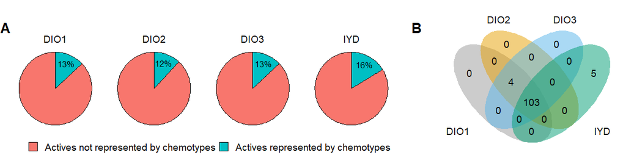

```r
aplusb <- plot_grid(piechart, NULL, venn_obj, rel_heights = c(1,1,1),
                    rel_widths = c(0.65, 0.05, 0.3),
                    nrow = 1,
                    labels = c("A", "B"),
                    label_x = -0.01, label_y = 0.9, label_size = 10) +
  theme(plot.background = element_rect(fill = "white", color = "white"))

print(aplusb)
```

```r
# separate into two figures: Figure 4
ggsave(plot = aplusb,
       units = "mm",
       dpi = 300,
       width = 140, height = 36,
       device = "png",
       filename = "./figures/longchainc_panactive_pie&venn.png")

ggsave(plot = aplusb,
       units = "mm",
       dpi = 300,
       width = 140, height = 36,
       device = "tiff",
       filename = "./figures/300dpi/longchainc_panactive_pie&venn.tiff")
```

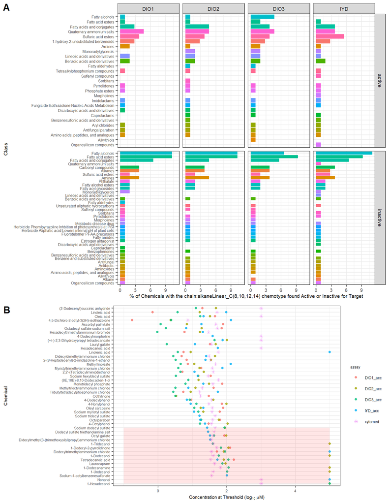

```r
cplusd <- plot_grid(barchart, dotplot, rel_heights = c(0.6, 0.4),
                    nrow = 2,
                    axis = "l",
                    labels = c("A", "B"),
                    label_x = 0, label_y = 1, label_size = 15)

print(cplusd)
```

```r
# Figure 5
ggsave(plot = cplusd,
       units = "mm",
       dpi = 600,
       width = 190, height = 240,
       device = "png",
       filename = "./figures/longchainc_panactive_class&sel.png")

ggsave(plot = cplusd,
       units = "mm",
       dpi = 600,
       width = 190, height = 240,
       device = "tiff",
       filename = "./figures/300dpi/longchainc_panactive_class&sel.tiff")


# combining them into one pg makes text in C&D small
# fig <- plot_grid(aplusb, cplusd,
#           rel_heights = c(0.15, 0.85), rel_widths = c(1,1), nrow = 2)
#
# fig
#
# ggsave(plot = fig,
#        units = "mm",
#        dpi = 300,
#        width = 190, height = 240,
#        device = "tiff",
#        filename = "./figures/300dpi/longchainc_panactive_v2.tiff")
#
# ggsave(plot = fig,
#        units = "mm",
#        dpi = 300,
#        width = 190, height = 240,
#        device = "png",
#        filename = "./figures/longchainc_panactive_v2.png")

# save to RData for later processing
# save(longchainc.chems,
#      M.hitc,
#      classified_dt,
#      file = "./data/invitrodb_v3_5_deiod_Enrichment.RData")
```

## function to make plots for each ToxPrint grouping

```r
make_plots <- function(chemotypes, piechart.actives = T) {
  tp.sub <- as.data.frame(toxprints[, c("DTXSID", ..chemotypes)])
  rownames(tp.sub) <- tp.sub$DTXSID
  tp.sub <- tp.sub[, -1, drop = FALSE]
  tp.sub <- na.omit(tp.sub)

  # get chems that have at least one of the enriched chemotypes
  chems <- rownames(tp.sub[rowSums(tp.sub) > 0, , drop = FALSE])

  # plot the chems with available selectivity (had to be tested in mc)
  # most of these are positive but not all
  sel.data <- acc_wide[dsstox_substance_id %in% chems,
                       .(dsstox_substance_id, chnm, DIO1_acc, DIO2_acc, DIO3_acc, IYD_acc, cytomed, max_selectivity)]

  sel.m <- melt.data.table(sel.data,
                           measure.vars = c(paste0(aenm.abbrevs, "_acc"), "cytomed"),
                           variable.name = "assay",
                           value.name = "acc")

  sel.m <- sel.m[!is.na(acc)]
  sel.m <- sel.m[order(-max_selectivity, -chnm)]

  # standardize themes
  my_theme <- theme_bw() +
    theme(axis.text = element_text(size = 10),
          legend.text = element_text(size = 10))

  # SELECTIVITY DOTPLOT
  dotplot <- ggplot(data = sel.m,
         mapping = aes(x = reorder(chnm,max_selectivity),
                       y = acc)) +
    geom_point(aes(color = assay, shape = assay),
               alpha = 0.8,
               size = 2.5) +
    scale_shape_manual(values = c("DIO1_acc" = 16, "DIO2_acc" = 16,
                                  "DIO3_acc" = 16, "IYD_acc" = 16,
                                  "cytomed" = 8)) +
    annotate("rect", xmin = sel.m[max_selectivity < 0.3][1, chnm],
             xmax = tail(sel.m[max_selectivity < 0.3], n = 1)[, chnm],
             ymin = floor(min(sel.m$acc)), ymax = ceiling(max(sel.m$acc)),
             alpha = .1, fill = "red") +
    my_theme +
    labs(x = 'Chemical', y = 'Concentration at Threshold (log uM)') +
    coord_flip()

  # how many of these chems were tested within each assay?
  totals.by.assay <- merged_dat[dsstox_substance_id %in% chems,
                       .(total = length(unique(dsstox_substance_id))), by = assay]

  testedChems.by.assay <- lapply(aenm.abbrevs, function(ae) {
    merged_dat[assay == ae & dsstox_substance_id %in% chems, dsstox_substance_id]
  })
  names(testedChems.by.assay) <- aenm.abbrevs

  # VENN DIAGRAM OF SUBSTANCES WITH CHEMOTYPE THAT WERE TESTED
  venn_obj <- ggvenn(testedChems.by.assay,
         show_percentage = FALSE,
         fill_color = c("#999999", "#E69F00", "#56B4E9", "#009E73"),
         stroke_linetype = "blank",
         text_size = 4,
         set_name_size = 3.8) +
    scale_y_continuous(expand = expansion(mult = .1))

  # class x hitc distribution of these chems
  actives <- merged_dat[dsstox_substance_id %in% chems & hitc == 1,
    .(count = length(unique(dsstox_substance_id))),
    by = .(assay, class_type, chosen_class)]
  actives[, hitcall := "active"]

  inactives <- merged_dat[dsstox_substance_id %in% chems & hitc == 0,
    .(count = length(unique(dsstox_substance_id))),
    by = .(assay, class_type, chosen_class)]
  inactives[, hitcall := "inactive"]

  class.hitc.dist <- setDT(bind_rows(actives, inactives))

  # add stats pertaining to each assay
  for (i in 1:length(h.deiod.aenm)) {
    class.hitc.dist[assay == aenm.abbrevs[i], `:=` (
      Nactives = hitc.dist[aenm == h.deiod.aenm[i] & hitc == 1, numChems], # total num of actives in that assay
      Ninactives = hitc.dist[aenm == h.deiod.aenm[i] & hitc == 0, numChems], # total num of inactives in that assay
      Nchemotypes = totals.by.assay[assay == aenm.abbrevs[i], total] # total num of chems described by the chemotypes of interest in each assay
  )]}

  class.hitc.dist[hitcall == "active", `:=` (pct = (count/Nactives)*100,
                                      pct_of_Nchemotypes = (count/Nchemotypes)*100
  )]

  class.hitc.dist[hitcall == "inactive", `:=` (pct = (count/Ninactives)*100,
                                      pct_of_Nchemotypes = (count/Nchemotypes)*100
  )]
  class.hitc.dist <- class.hitc.dist[order(-pct_of_Nchemotypes), .SD, keyby = .(assay, hitcall)]

  # CLASS DISTRIBUTION OF CHEMS WITH CHEMOTYPE(S)
  barchart <- ggplot(class.hitc.dist,
         aes(x= reorder(chosen_class, pct_of_Nchemotypes),
             y=pct_of_Nchemotypes, fill=chosen_class)) +
    geom_bar(stat="identity") +
    my_theme +
    theme(legend.position = "none",
         plot.title.position = "plot",
         plot.title = element_text(hjust = 0.15, vjust = 0.6)) +
    coord_flip() +
    facet_grid(hitcall ~ assay, scales = "free_y") +
    labs(x = "Class",
         y = "% of Chemicals with Given Chemotype(s) found Active or Inactive for Target",
         title = "Class Distribution of Chemicals with Chemotype(s)")

  if (piechart.actives) {
    class.hitc.dist[hitcall == "active", total_pct := sum(pct), by = assay]
  }
  else {
    class.hitc.dist[hitcall == "inactive", total_pct := sum(pct), by = assay]
  }

  pie.per.assay <- unique(class.hitc.dist[!is.na(total_pct), .(total_pct, assay)])
  pie.per.assay[, in_group := T]

  other.chunk <- pie.per.assay %>%
    arrange(assay) %>%
    mutate(total_pct = 100-total_pct,
           in_group = FALSE)

  pie.data <- rbind(pie.per.assay, other.chunk)

  # compute the position of labels
  pie.data <- pie.data %>%
    arrange(assay, desc(in_group)) %>%
    mutate(ypos = cumsum(total_pct)- 0.5*total_pct)

  # % OF ACTIVES or INACTIVES AS A PIECHART
  if (piechart.actives) {
    key.labels <- c("Actives not represented by chemotypes", "Actives represented by chemotypes")
  } else {
    key.labels <- c("Inactives not represented by chemotypes", "Inactives represented by chemotypes")
  }
  piechart <- ggplot(pie.data,
                     aes(x="", y=total_pct, fill = in_group)) +
    geom_bar(stat="identity", width = 1, color = "black") +
    coord_polar("y", start=0) +
    ylim(0, 100) +
    scale_fill_discrete(name = "",
                        labels = key.labels) +
    facet_wrap(~ assay, nrow =  1) +
    geom_text(aes(x = 1.25, label = ifelse(in_group, paste0(round(total_pct, digits = 1), "%"), "")),
              color = "black", size = 13/.pt,
              position = position_stack(vjust = 0.5)) +
    theme_void() +
    theme(legend.position = "bottom",
          legend.text = element_text(size = 12),
          text = element_text(size = 14),
          plot.margin = unit(c(1,0.5,0,0.5), "lines"))

  aplusb <- plot_grid(piechart, NULL, venn_obj, rel_heights = c(1,1,1),
                      rel_widths = c(0.7, 0.05, 0.3),
                      nrow = 1,
                      labels = c("A", "B"),
                      label_x = 0, label_y = 0.8, label_size = 20)

  cplusd <- plot_grid(barchart, dotplot, rel_heights = c(1.4, 1),
                      rel_widths = c(1, 0.5),
                      nrow = 2,
                      labels = c("C", "D"),
                      label_x = 0, label_y = 1, label_size = 20)

  fig <- plot_grid(aplusb, cplusd,
            rel_heights = c(0.2, 0.8), rel_widths = c(1,1), nrow = 2)

  return(fig)

}
```

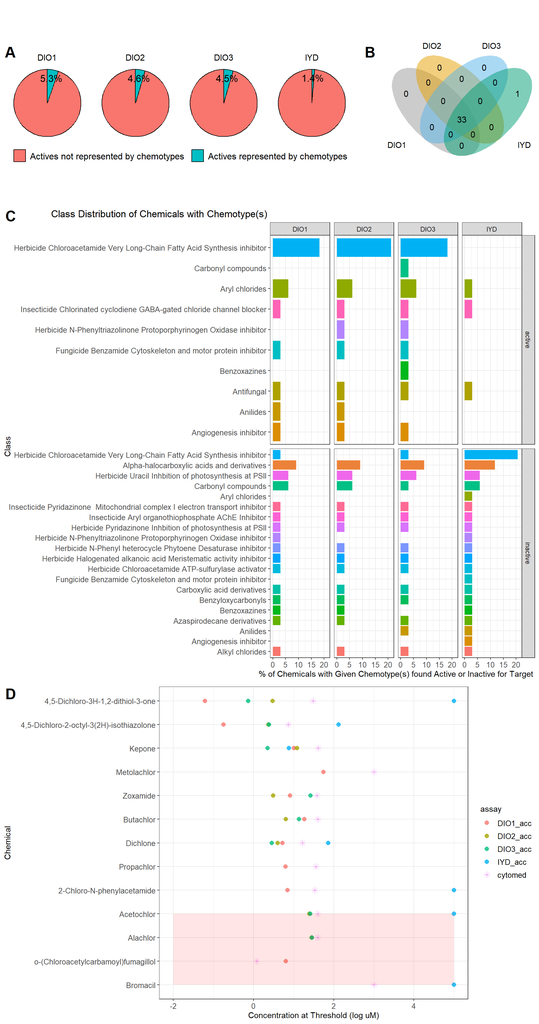

```r
ahalo.res <- make_plots(c("bond:C(~Z)~C~Q_a-halocarbonyl"))
ahalo.res
```

## chain:alkeneLinear_[mono-ene|diene]_* (enriched for DIO1-3)

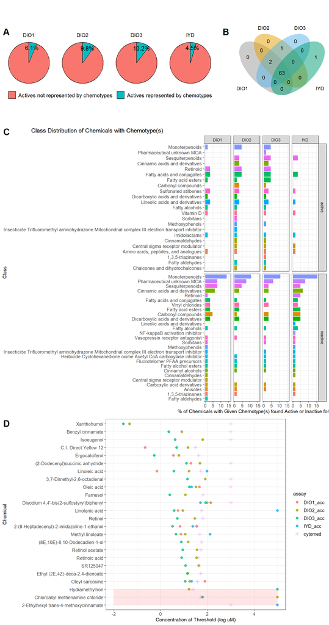

```r
alk.lin.group <- rownames(M.active[rs.active == 3, ])[3:6]
alk.lin.res <- make_plots(alk.lin.group)
alk.lin.res
```

## bond:CX_halide_alkyl-F_perfluoro_octyl (enriched for DIO1/2/IYD)

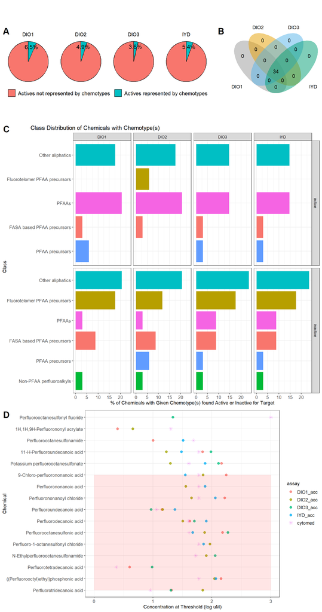

```r
halide.res <- make_plots(c("bond:CX_halide_alkyl-F_perfluoro_octyl"))
halide.res
```

## chain:aromaticAlkene_Ph-C2_acyclic_generic (enriched for DIO2/3/IYD)

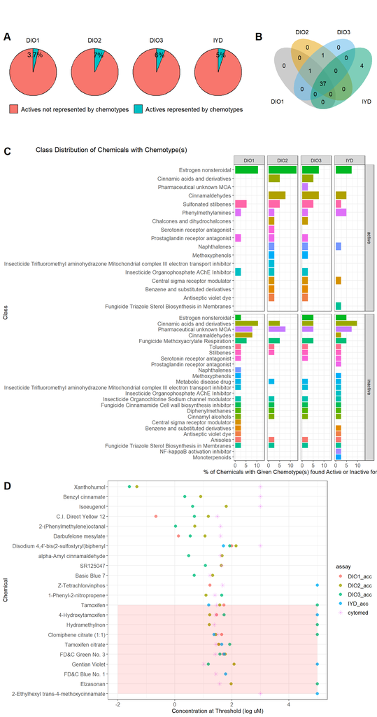

```r
arom.alk.res <- make_plots(c("chain:aromaticAlkene_Ph-C2_acyclic_generic"))
arom.alk.res
```

## chain:aromaticAlkane_Ph-C6 (enriched for DIO1/2/IYD)

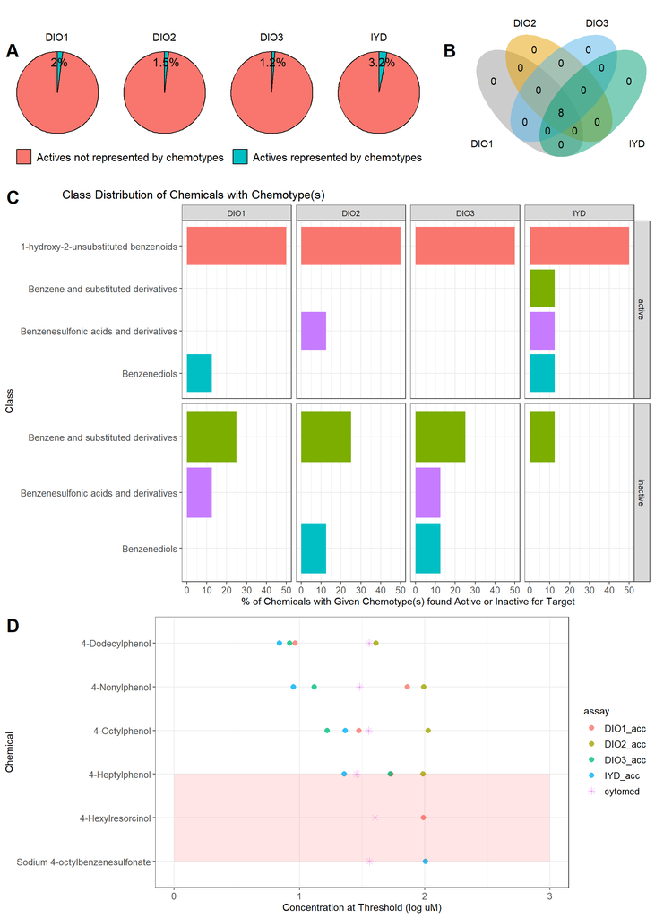

```r
arom.alk.c6 <- make_plots(c("chain:aromaticAlkane_Ph-C6"))
arom.alk.c6
```

## chain:alkene[Branch|Linear]*mono-ene** (enriched for DIO2/3)

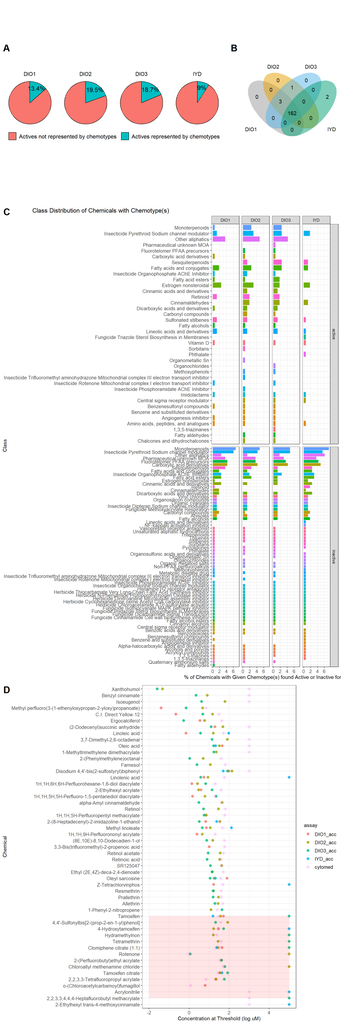

```r
mono.ene.group <- rownames(M.active[rs.active == 2, ])[4:6]
mono.ene.res <- make_plots(mono.ene.group)
mono.ene.res
```

## chain:aromaticAlkene_Ph-C2_(styrene)* (enriched for DIO2/3)

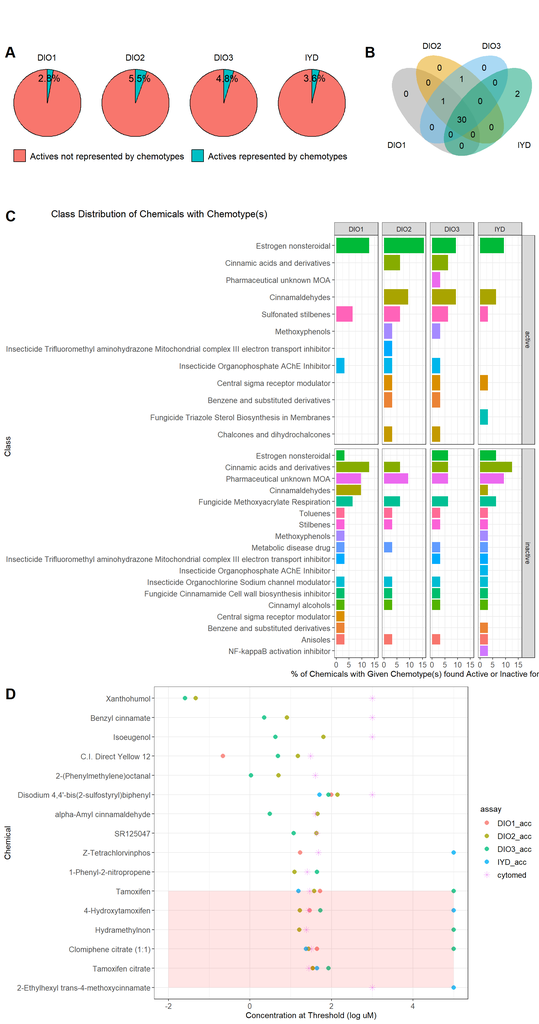

```r
ring.ph.c2 <- rownames(M.active[rs.active == 2, ])[10:11]
ring.phc2.res <- make_plots(ring.ph.c2)
ring.phc2.res
```

## bond:quatN_alkyl_acyclic (enriched for DIO1/IYD)

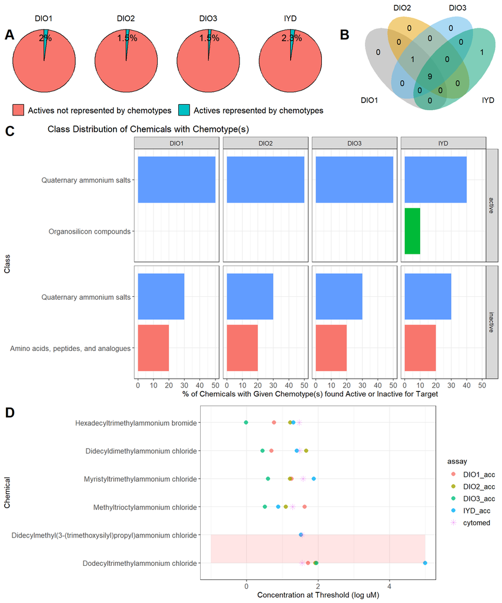

```r
quatN.res <- make_plots(c("bond:quatN_alkyl_acyclic"))
quatN.res
```

## bond:CC(=O)C_ketone_alkene_cyclic_3-en-1-one (enriched for DIO1/3)

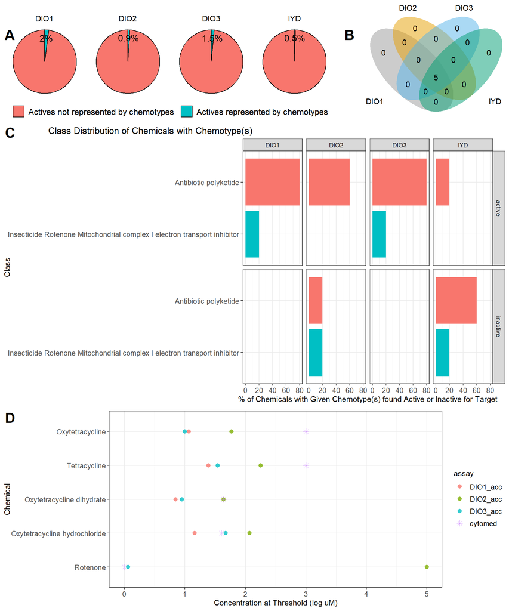

```r
ketone.alk.res <- make_plots(c("bond:CC(=O)C_ketone_alkene_cyclic_3-en-1-one"))
ketone.alk.res
```

## chain:aromaticAlkane_[Ar|Ph]-C(1)*-[Ar|Ph] (enriched for DIO2/IYD)

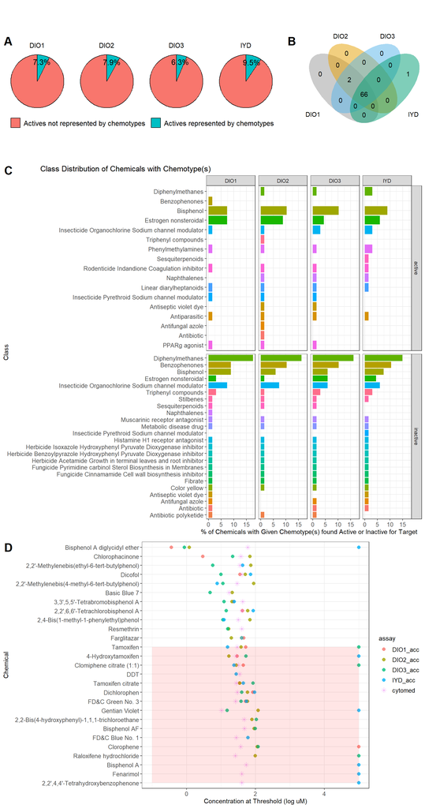

```r
arom.alk.xcx.group <- rownames(M.active[rs.active == 2, ])[7:8]
arom.alk.XCX.res <- make_plots(arom.alk.xcx.group)
arom.alk.XCX.res
```

## chain:alkaneLinear_hexadecyl_C16 (enriched for DIO2/IYD)

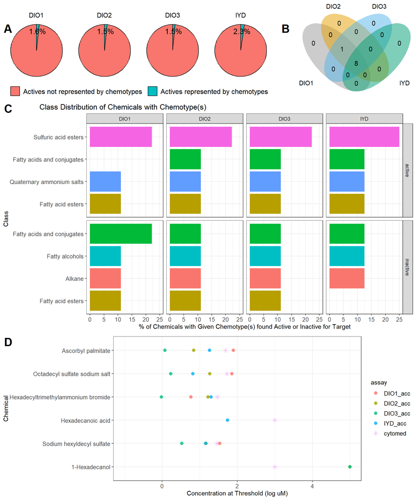

```r
longc16.res <- make_plots("chain:alkaneLinear_hexadecyl_C16")
longc16.res
```

# Enriched just for DIO1

## bond:CC(=O)C_ketone_aromatic_aliphatic

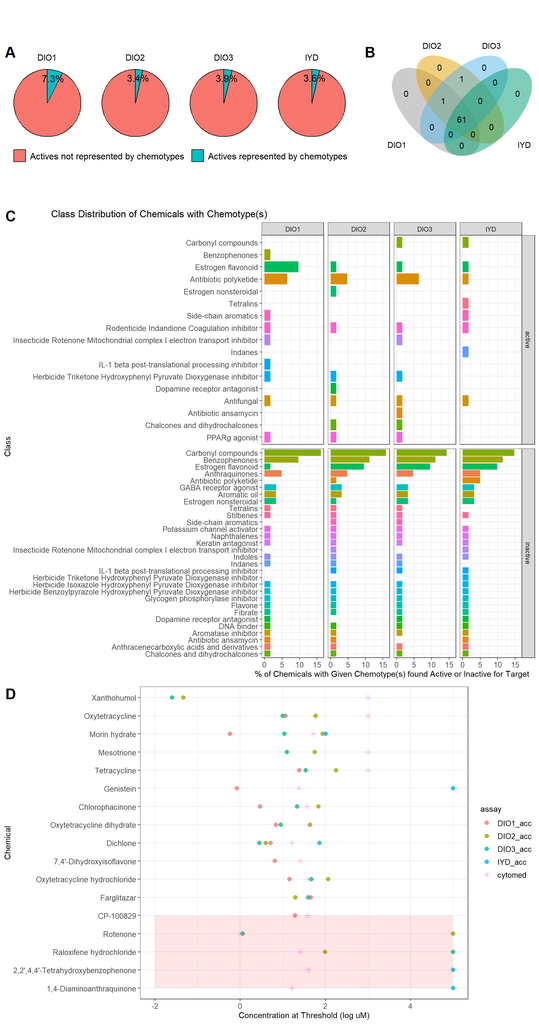

```r
ketone.dio1.res <- make_plots(c("bond:CC(=O)C_ketone_aromatic_aliphatic"))
ketone.dio1.res
```

## bond:[CO(C|H)]*[ether|alcohol]*[alkenyl|alkene]_*

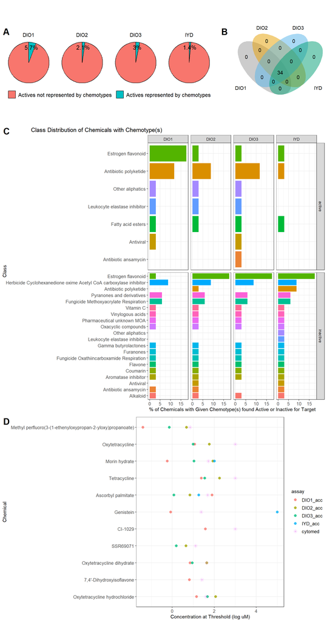

```r
alcoh.ethers <- rownames(subset(M.active, DIO1 == 1 & DIO2 == 0 & DIO3 == 0 & IYD == 0))[2:4]

alcohol.res <- make_plots(alcoh.ethers)
alcohol.res
```

[figure not shown]

```r
bonds.w.sulfur <- rownames(subset(M.active, DIO1 == 1 & DIO2 == 0 & DIO3 == 0 & IYD == 0))[c(5,7,8)]

sulfur.res <- make_plots(bonds.w.sulfur)
sulfur.res
```

## ring:hetero_[6_6]*O_benzopyrone*(1_4-)

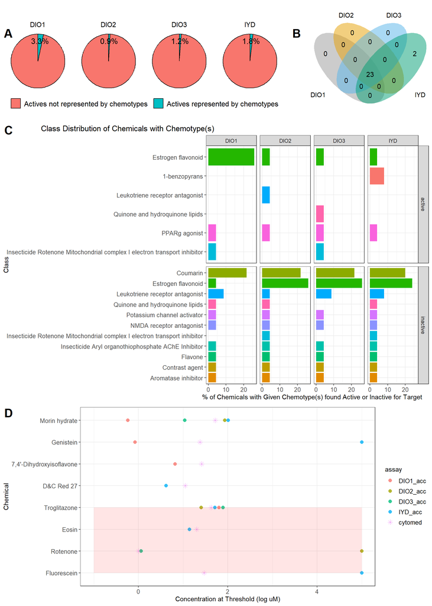

```r
ring.dio1.res <- make_plots(c("ring:hetero_[6_6]_O_benzopyrone_(1_4-)", "ring:hetero_[6_6]_O_benzopyran"))
ring.dio1.res
```

## bond:P=O_phosphate_thioate

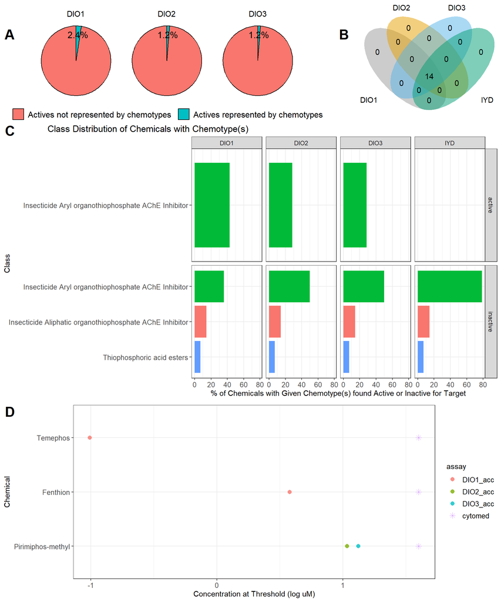

```r
thioate.res <- make_plots(c("bond:P=O_phosphate_thioate"))
thioate.res
```

# DIO2

## chain:alkeneLinear_diene_1_4-diene

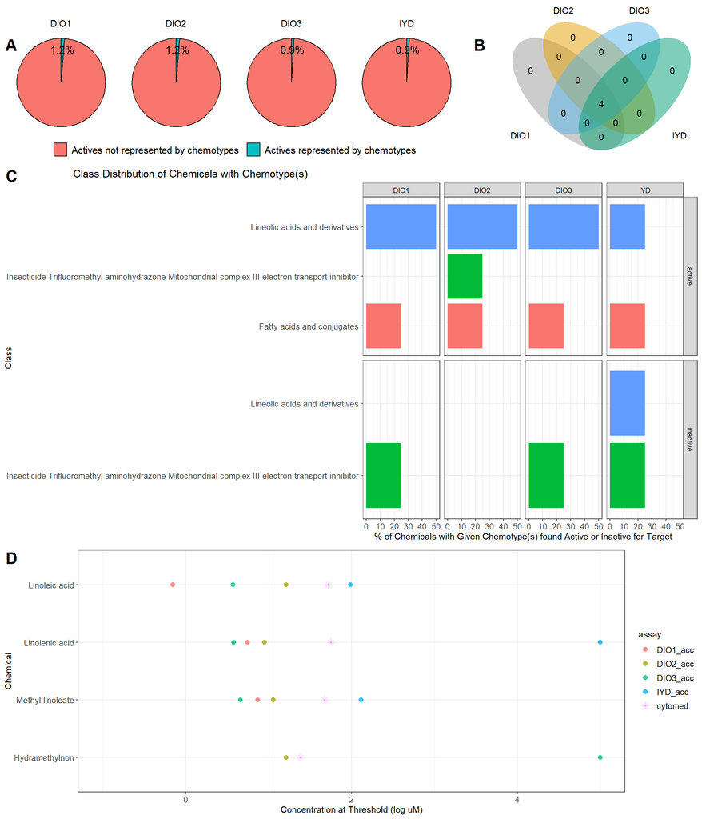

```r
chain.dio2.res <- make_plots(c("chain:alkeneLinear_diene_1_4-diene"))
chain.dio2.res
```

# DIO3

## Carbonyls

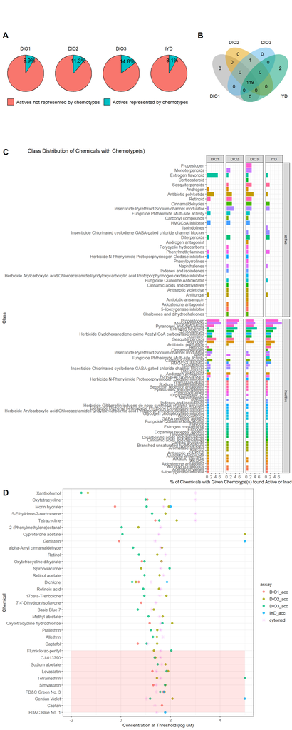

```r
carbonyls <- c("bond:C=O_carbonyl_ab-unsaturated_aliphatic_(michael_acceptors)",
               "bond:CC(=O)C_ketone_alkene_generic",
               "chain:alkeneCyclic_ethene_C_(connect_noZ)")

carbonyl.res <- make_plots(carbonyls)
carbonyl.res
```

## Cyclohexenes

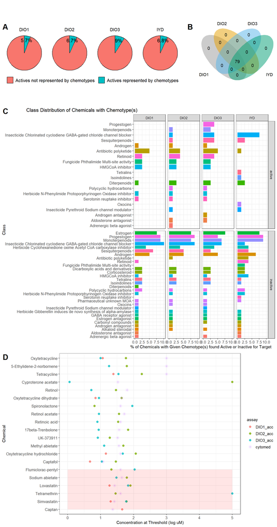

```r
cyclohexenes <- c("bond:CC(=O)C_ketone_alkene_cyclic_(C6)",
                  "chain:alkeneCyclic_diene_cyclohexene")

cyclohex.res <- make_plots(cyclohexenes)
cyclohex.res
```

## bond:CN_amine_sec-NH_aromatic_aliphatic

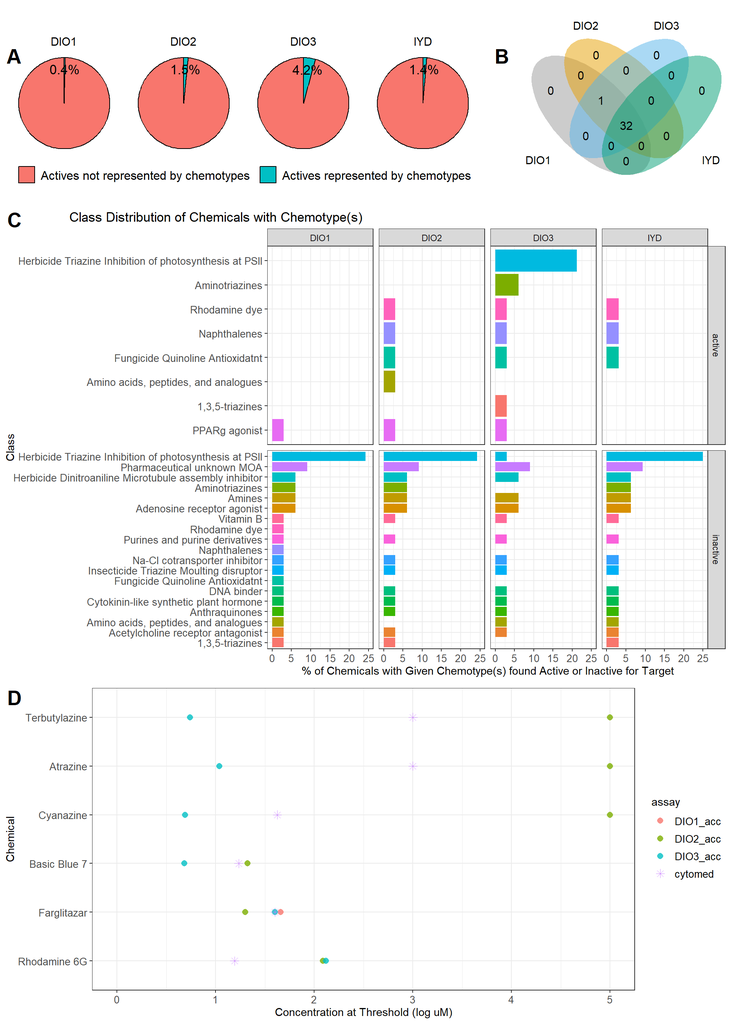

```r
amine.res <- make_plots(c("bond:CN_amine_sec-NH_aromatic_aliphatic"))
amine.res
```